background

# Pandas Library

pandas is an abbreviation for the **P**ython **an**d **D**ata **A**naly**s**is Library. It is a library that uses three main data structures:

- the Index class
- the Series class
- the DataFrame class

Most Index classes are numeric, that is zero-order integer steps of one.

The Index, similar to a tuple, list or 1darray has a single dimension which can be represented either as a row:

| index | 0 | 1 | 2 | 3 |
| --- | --- | --- | --- | --- |

Or as a column when convenient:

| index |
| --- |
| 0 |
| 1 |
| 2 |
| 3 |

The Series class has a value at each index and a name. It is essentially a numpy 1darray that has a name. A Series is normally represented as a column (notice the Index associated with the Series is also displayed as a column):

| index | 'x' |
| --- | --- |
| 0 | 1.1 |
| 1 | 2.1 |
| 2 | 3.1 |
| 3 | 4.1 |

A DataFrame class is essentially a grouping of series instances that have the same index:

| index | 'x' | 'y' |
| --- | --- | --- |
| 0 | 1.1 | 1.2 |
| 1 | 2.1 | 2.2 |
| 2 | 3.1 | 3.2 |
| 3 | 4.1 | 4.2 |

## Categorize_Identifiers Module

This notebook will use the following functions `dir2`, `variables` and `view` in the custom module `categorize_identifiers` which is found in the same directory as this notebook file. `dir2` is a variant of `dir` that groups identifiers into a `dict` under categories and `variables` is an IPython based a variable inspector. `view` is used to view a `Collection` in more detail:

```python
from categorize_identifiers import dir2, variables, view
```

The following will be imported in order to simplify the output of `dir2`:

```python
import operator
reverse_operators = ['radd', 'rmod', 'rmul', 'rpow', 'rsub', 'rtruediv']
import obsolete
```

## Importing Libraries

To use the data science libraries they need to be imported:

```python
import numpy as np
import pandas as pd
```

Once imported the identifiers can be viewed:

```python
dir2(pd, exclude_external_modules=True, drop_internal=True, exclude_identifier_list=obsolete.pandas_depreciation)
```

```
{'attribute': ['annotations', 'options'],
 'constant': ['IndexSlice', 'NA', 'NaT'],
 'module': ['api',
            'arrays',
            'compat',
            'core',
            'errors',
            'io',
            'offsets',
            'pandas',
            'plotting',
            'testing',
            'tseries',
            'util'],
 'method': ['array',
            'bdate_range',
            'concat',
            'crosstab',
            'cut',
            'date_range',
            'describe_option',
            'eval',
            'factorize',
            'from_dummies',
            'get_dummies',
            'get_option',
            'infer_freq',
            'interval_range',
            'isna',
            'isnull',
            'json_normalize',
            'lreshape',
            'melt',
            'merge',
            'merge_asof',
            'merge_ordered',
            'notna',
            'notnull',
            'period_range',
            'pivot',
```

[output cut: 72 more lines]

```
                 'UInt64Dtype',
                 'UInt8Dtype'],
 'datamodel_attribute': ['__all__',
                         '__builtins__',
                         '__cached__',
                         '__doc__',
                         '__docformat__',
                         '__file__',
                         '__git_version__',
                         '__loader__',
                         '__name__',
                         '__package__',
                         '__path__',
                         '__spec__',
                         '__version__']}
```

In general `pd` uses object orientated programming (OOP) opposed to functional programming. Most of the functions within `pd` are used to read in data from a file and output a `pd.DataFrame` instance.

The classes are all in PascalCase. The main classes are:

- pd.Index
- pd.Series
- pd.DataFrame

The OOP approach means methods are normally called from instances to analyse or manipulate data from the instance. The identifiers for the main three classes can be examined. The relationship between the identifiers in the three classes above will first be examined before later examining the classes in detail.

The `pd.Series` can be conceptualised as a `np.ndarray` with a `name` and therefore has consistent attributes, methods and numerical datamodel methods:

```python
dir2(pd.Series, np.ndarray, consistent_only=True, exclude_external_modules=True, drop_internal=True, exclude_identifier_list=obsolete.series_depreciation)
```

```
{'attribute': ['dtype', 'flags', 'nbytes', 'ndim', 'shape', 'size'],
 'constant': ['T'],
 'method': ['all',
            'any',
            'argmax',
            'argmin',
            'argsort',
            'astype',
            'clip',
            'copy',
            'cumprod',
            'cumsum',
            'dot',
            'item',
            'max',
            'mean',
            'min',
            'prod',
            'repeat',
            'round',
            'searchsorted',
            'squeeze',
            'std',
            'sum',
            'take',
            'tolist',
            'transpose',
            'var'],
 'datamodel_attribute': ['__array_priority__', '__doc__', '__hash__'],
 'datamodel_method': ['__abs__',
                      '__add__',
                      '__and__',
                      '__array__',
                      '__array_ufunc__',
                      '__bool__',
                      '__class__',
                      '__contains__',
                      '__copy__',
                      '__deepcopy__',
                      '__delattr__',
```

[output cut: 48 more lines]

```
                      '__rmul__',
                      '__ror__',
                      '__rpow__',
                      '__rsub__',
                      '__rtruediv__',
                      '__rxor__',
                      '__setattr__',
                      '__setitem__',
                      '__setstate__',
                      '__sizeof__',
                      '__str__',
                      '__sub__',
                      '__subclasshook__',
                      '__truediv__',
                      '__xor__']}
```

A number of the `__builtins__` functions are also available as `pd.Series` methods:

```python
dir2(pd.Series, __builtins__, consistent_only=True, exclude_identifier_list=obsolete.series_depreciation)
```

```
{'method': ['abs',
            'all',
            'any',
            'divmod',
            'filter',
            'map',
            'max',
            'min',
            'pow',
            'round',
            'sum'],
 'lower_class': ['list', 'str'],
 'datamodel_attribute': ['__doc__']}
```

Many of the datamodel operators defined for numeric operation are also available as a method:

```python
dir2(pd.Series, operator, consistent_only=True)
```

```
{'attribute': ['index'],
 'method': ['abs',
            'add',
            'eq',
            'floordiv',
            'ge',
            'gt',
            'le',
            'lt',
            'mod',
            'mul',
            'ne',
            'pow',
            'sub',
            'truediv'],
 'datamodel_attribute': ['__doc__'],
 'datamodel_method': ['__abs__',
                      '__add__',
                      '__and__',
                      '__contains__',
                      '__delitem__',
                      '__eq__',
                      '__floordiv__',
                      '__ge__',
                      '__getitem__',
                      '__gt__',
                      '__iadd__',
                      '__iand__',
                      '__ifloordiv__',
                      '__imod__',
                      '__imul__',
                      '__invert__',
                      '__ior__',
                      '__ipow__',
                      '__isub__',
                      '__itruediv__',
                      '__ixor__',
                      '__le__',
                      '__lt__',
                      '__matmul__',
                      '__mod__',
                      '__mul__',
                      '__ne__',
                      '__neg__',
                      '__or__',
                      '__pos__',
                      '__pow__',
                      '__setitem__',
                      '__sub__',
                      '__truediv__',
                      '__xor__']}
```

The `pd.Series` has additional methods. Many of these are statistical methods and have a similar name to functions found in the statistics module. There are also a large number of `to` methods which convert the `pd.Series` to another datatype or file format.

There are also lowercase classes:

- `str` which groups together `str` identifiers
- `cat` which groups together category identifiers
- `dt` which groups together datetime (`datetime.datetime` or `datetime.timedelta`) identifiers
- `plot` which groups together `pyplot` based functions which can be use on the values
- `list` which groups together `list[pyarrow]` identifiers (`pyarrow` features are still experimental)

The lowercase classes are appropriate when the `pd.Series` datatype matches one of the class types above.

```python
dir2(pd.Series, [np.ndarray, operator], unique_only=True,
     exclude_external_modules=True, exclude_identifier_list=reverse_operators+obsolete.series_depreciation, drop_internal=True)
```

```
{'attribute': ['array',
               'at',
               'attrs',
               'axes',
               'dtypes',
               'empty',
               'hasnans',
               'iat',
               'iloc',
               'is_monotonic_decreasing',
               'is_monotonic_increasing',
               'is_unique',
               'loc',
               'name',
               'values'],
 'method': ['add_prefix',
            'add_suffix',
            'agg',
            'aggregate',
            'align',
            'apply',
            'asfreq',
            'asof',
            'at_time',
            'autocorr',
            'between',
            'between_time',
            'bfill',
            'case_when',
            'combine',
            'combine_first',
            'compare',
            'convert_dtypes',
            'corr',
            'count',
            'cov',
            'cummax',
            'cummin',
            'describe',
            'diff',
```

[output cut: 100 more lines]

```
            'update',
            'value_counts',
            'where',
            'xs'],
 'lower_class': ['cat', 'dt', 'list', 'plot', 'sparse', 'str', 'struct'],
 'datamodel_attribute': ['__annotations__',
                         '__dict__',
                         '__module__',
                         '__pandas_priority__',
                         '__weakref__'],
 'datamodel_method': ['__column_consortium_standard__',
                      '__finalize__',
                      '__getattr__',
                      '__nonzero__',
                      '__round__']}
```

A `pd.DataFrame` is essentially a grouping of `pd.Series` instances and therefore has many identifiers in common.

The attributes `dtypes` and `values` are used as plural equivalents to `dtype` and `array` seen in the `pd.Series`. `dtypes` reflects the fact each `pd.Series` in the `pd.DataFrame` instance can have a different datatype. However when each `pd.Series` are numeric then `pd.values` is the 2d `ndarray` instance. Most of the statistical methods will only also work when each `pd.Series` in the `pd.DataFrame` instance are numeric. It is more common to use statistical functions on a `pd.Series`.

```python
dir2(pd.DataFrame, pd.Series, consistent_only=True, drop_internal=True, exclude_identifier_list=obsolete.df_depreciation)
```

```
{'attribute': ['at',
               'attrs',
               'axes',
               'dtypes',
               'empty',
               'flags',
               'iat',
               'iloc',
               'index',
               'loc',
               'ndim',
               'shape',
               'size',
               'values'],
 'constant': ['T'],
 'method': ['abs',
            'add',
            'add_prefix',
            'add_suffix',
            'agg',
            'aggregate',
            'align',
            'all',
            'any',
            'apply',
            'asfreq',
            'asof',
            'astype',
            'at_time',
            'backfill',
            'between_time',
            'bfill',
            'clip',
            'combine',
            'combine_first',
            'compare',
            'convert_dtypes',
            'copy',
            'corr',
            'count',
```

[output cut: 203 more lines]

```
                      '__ror__',
                      '__round__',
                      '__rpow__',
                      '__rsub__',
                      '__rtruediv__',
                      '__rxor__',
                      '__setattr__',
                      '__setitem__',
                      '__setstate__',
                      '__sizeof__',
                      '__str__',
                      '__sub__',
                      '__subclasshook__',
                      '__truediv__',
                      '__xor__']}
```

The `pd.DataFrame` class only has a small number of additional identifiers such as the attributes `columns` which is a `list` of `str` instances with each `str` corresponding to the appropriate `pd.Series.name` available in the `pd.DataFrame`. The `pd.DataFrame` instance is mutable and the `insert` method can be used to insert another `pd.Series` instance. `join` and `merge` are used to join and merge `pd.DataFrame` instances.

The `style` attribute is an additional attribute which can be used to control the style of the `pd.DataFrame` instance when displayed in a cell output.

```python
dir2(pd.DataFrame, pd.Series, unique_only=True, drop_internal=True, exclude_identifier_list=obsolete.df_depreciation)
```

```
{'attribute': ['columns', 'style'],
 'method': ['assign',
            'boxplot',
            'corrwith',
            'eval',
            'from_dict',
            'from_records',
            'insert',
            'isetitem',
            'iterrows',
            'itertuples',
            'join',
            'melt',
            'merge',
            'pivot',
            'pivot_table',
            'query',
            'select_dtypes',
            'set_index',
            'stack',
            'to_feather',
            'to_html',
            'to_orc',
            'to_parquet',
            'to_records',
            'to_stata',
            'to_xml'],
 'datamodel_method': ['__arrow_c_stream__',
                      '__dataframe__',
                      '__dataframe_consortium_standard__']}
```

The identifiers in a `pd.Series` instance are singular identifiers typically only used across a `pd.Series` instance. These include the lowercase classes used to work a specific datatype across a `pd.Series`:

```python
dir2(pd.Series, pd.DataFrame, unique_only=True, drop_internal=True, exclude_identifier_list=obsolete.series_depreciation)
```

```
{'attribute': ['array',
               'dtype',
               'hasnans',
               'is_monotonic_decreasing',
               'is_monotonic_increasing',
               'is_unique',
               'name',
               'nbytes'],
 'method': ['argmax',
            'argmin',
            'argsort',
            'autocorr',
            'between',
            'case_when',
            'divmod',
            'factorize',
            'item',
            'rdivmod',
            'repeat',
            'searchsorted',
            'to_frame',
            'to_list',
            'tolist',
            'unique'],
 'lower_class': ['cat', 'dt', 'list', 'str', 'struct'],
 'datamodel_method': ['__column_consortium_standard__', '__float__', '__int__']}
```

Each `pd.Series` is associated with a `pd.Index` and every `pd.Series` in a `pd.DataFrame` uses the same `pd.Index`. Many identifiers for the `pd.Index` can be seen to be consistent with a `pd.Series` as it is also based on an `np.ndarray`:

```python
dir2(pd.Index, pd.Series, consistent_only=True, exclude_external_modules=True, drop_internal=True, exclude_identifier_list=obsolete.index_depreciation)
```

```
{'attribute': ['array',
               'dtype',
               'empty',
               'hasnans',
               'is_monotonic_decreasing',
               'is_monotonic_increasing',
               'is_unique',
               'name',
               'nbytes',
               'ndim',
               'shape',
               'size',
               'values'],
 'constant': ['T'],
 'method': ['all',
            'any',
            'argmax',
            'argmin',
            'argsort',
            'asof',
            'astype',
            'copy',
            'diff',
            'drop',
            'drop_duplicates',
            'droplevel',
            'dropna',
            'duplicated',
            'equals',
            'factorize',
            'fillna',
            'groupby',
            'infer_objects',
            'isin',
            'isna',
            'isnull',
            'item',
            'map',
            'max',
            'memory_usage',
```

[output cut: 76 more lines]

```
                      '__rmod__',
                      '__rmul__',
                      '__ror__',
                      '__rpow__',
                      '__rsub__',
                      '__rtruediv__',
                      '__rxor__',
                      '__setattr__',
                      '__setitem__',
                      '__sizeof__',
                      '__str__',
                      '__sub__',
                      '__subclasshook__',
                      '__truediv__',
                      '__xor__']}
```

the `pd.Index` class only has a small number of identifiers not found in a `pd.Series` instance. The `pd.Index` is typically numeric but each value in the `Series` can be assigned a `name` and the attribute `names` retrieves these. Typically each `name` should be unique for the purpose of indexing and the attribute `has_duplicates` is used to check for duplicate values and the `pd.Series` or `pd.DataFrame` method `reset_index` can be used in this case to return a unique index of numeric values. More complicated indexes can be multilevel and the `nlevels` attribute gives details about the amount of levels in the index:

```python
dir2(pd.Index, pd.Series, unique_only=True, exclude_external_modules=True, drop_internal=True, exclude_identifier_list=obsolete.index_depreciation)
```

```
{'attribute': ['has_duplicates', 'inferred_type', 'names', 'nlevels'],
 'method': ['append',
            'asof_locs',
            'delete',
            'difference',
            'get_indexer',
            'get_indexer_for',
            'get_indexer_non_unique',
            'get_level_values',
            'get_loc',
            'get_slice_bound',
            'identical',
            'insert',
            'intersection',
            'is_',
            'join',
            'putmask',
            'set_names',
            'slice_indexer',
            'slice_locs',
            'sort',
            'sortlevel',
            'symmetric_difference',
            'to_flat_index',
            'to_series',
            'union'],
 'datamodel_method': ['__array_wrap__']}
```

## Series

The initialisation signature for the `pd.Series` class can be examined:

```python
pd.Series?
```

```
Init signature:
pd.Series(
    data=None,
    index=None,
    dtype: 'Dtype | None' = None,
    name=None,
    copy: 'bool | None' = None,
    fastpath: 'bool | lib.NoDefault' = <no_default>,
) -> 'None'
Docstring:
One-dimensional ndarray with axis labels (including time series).

Labels need not be unique but must be a hashable type. The object
supports both integer- and label-based indexing and provides a host of
methods for performing operations involving the index. Statistical
methods from ndarray have been overridden to automatically exclude
missing data (currently represented as NaN).

Operations between Series (+, -, /, \*, \*\*) align values based on their
associated index values-- they need not be the same length. The result
index will be the sorted union of the two indexes.

Parameters
----------
data : array-like, Iterable, dict, or scalar value
    Contains data stored in Series. If data is a dict, argument order is
    maintained.
index : array-like or Index (1d)
    Values must be hashable and have the same length as `data`.
    Non-unique index values are allowed. Will default to
    RangeIndex (0, 1, 2, ..., n) if not provided. If data is dict-like
    and index is None, then the keys in the data are used as the index. If the
    index is not None, the resulting Series is reindexed with the index values.
dtype : str, numpy.dtype, or ExtensionDtype, optional
    Data type for the output Series. If not specified, this will be
    inferred from `data`.
    See the :ref:`user guide <basics.dtypes>` for more usages.
name : Hashable, default None
    The name to give to the Series.
copy : bool, default False
```

[output cut: 52 more lines]

```
>>> ser = pd.Series(r, copy=False)
>>> ser.iloc[0] = 999
>>> r
array([999,   2])
>>> ser
0    999
1      2
dtype: int64

Due to input data type the Series has a `view` on
the original data, so
the data is changed as well.
File:           c:\users\phili\anaconda3\envs\vscode-env\lib\site-packages\pandas\core\series.py
Type:           type
Subclasses:     SubclassedSeries
```

The main keyword input arguments are:

- data
- index
- dtype
- name

If these are not supplied an empty series instance with no index, no name and a generic object datatype is instantiated:

```python
pd.Series()
```

```
Series([], dtype: object)
```

Normally data is supplied in the form of a numpy 1darray:

```python
pd.Series(data=np.array([1, 2, 3]))
```

```
0    1
1    2
2    3
dtype: int32
```

Since a ndarray itself is initialised from a list, this can be abbreviated to:

```python
pd.Series(data=[1, 2, 3])
```

```
0    1
1    2
2    3
dtype: int64
```

When `dtype=None`, the data type will be inferred from the data:

```python
pd.Series(data=[1., 2., 3.])
```

```
0    1.0
1    2.0
2    3.0
dtype: float64
```

```python
from datetime import datetime, timedelta
pd.Series(data=[datetime.now(),
                datetime.now() + timedelta(days=1),
                datetime.now() + timedelta(days=2)])
```

```
0   2024-02-15 01:23:45.711586
1   2024-02-16 01:23:45.711586
2   2024-02-17 01:23:45.711586
dtype: datetime64[ns]
```

```python
pd.Series(data=['a', 'b', 'c'])
```

```
0    a
1    b
2    c
dtype: object
```

Anything with a `str` in it is classed as non-numeric and has the generic dtype `object` (meaning it can be any Python object).

The dtype can be manually overidden when supplying the numpy 1darray by using the `np.array` input argument `dtype`:

```python
pd.Series(data=np.array([1., 2., 3.], dtype=np.int32))
```

```
0    1
1    2
2    3
dtype: int32
```

Or by alternatively using the `Series` keyword input argument `dtype`:

```python
pd.Series(data=[1., 2., 3.], dtype=np.int32)
```

```
0    1
1    2
2    3
dtype: int32
```

Notice that the index is zero-ordered numeric in integer steps of 1 by default. This can be manually changed by use of the keyword input argument `index` and providing an `Index` instance, `ndarray` instance or `list` instance of index values:

```python
pd.Series(index=['a', 'b', 'c'], data=[1., 2., 3.], dtype=np.int32)
```

```
a    1
b    2
c    3
dtype: int32
```

A `Series` usually also has a `name`:

```python
pd.Series(index=['a', 'b', 'c'], data=[1., 2., 3.], dtype=np.int32, name='x')
```

```
a    1
b    2
c    3
Name: x, dtype: int32
```

Normally the `data` and `name` are supplied and the `index` and `dtype` are inferred:

```python
pd.Series([1.1, 2.1, 3.1, 4.1], name='x')
```

```
0    1.1
1    2.1
2    3.1
3    4.1
Name: x, dtype: float64
```

## DataFrame

The initialisation signature for the `pd.DataFrame` class can be examined:

```python
pd.DataFrame?
```

```
Init signature:
pd.DataFrame(
    data=None,
    index: 'Axes | None' = None,
    columns: 'Axes | None' = None,
    dtype: 'Dtype | None' = None,
    copy: 'bool | None' = None,
) -> 'None'
Docstring:
Two-dimensional, size-mutable, potentially heterogeneous tabular data.

Data structure also contains labeled axes (rows and columns).
Arithmetic operations align on both row and column labels. Can be
thought of as a dict-like container for Series objects. The primary
pandas data structure.

Parameters
----------
data : ndarray (structured or homogeneous), Iterable, dict, or DataFrame
    Dict can contain Series, arrays, constants, dataclass or list-like objects. If
    data is a dict, column order follows insertion-order. If a dict contains Series
    which have an index defined, it is aligned by its index. This alignment also
    occurs if data is a Series or a DataFrame itself. Alignment is done on
    Series/DataFrame inputs.

    If data is a list of dicts, column order follows insertion-order.

index : Index or array-like
    Index to use for resulting frame. Will default to RangeIndex if
    no indexing information part of input data and no index provided.
columns : Index or array-like
    Column labels to use for resulting frame when data does not have them,
    defaulting to RangeIndex(0, 1, 2, ..., n). If data contains column labels,
    will perform column selection instead.
dtype : dtype, default None
    Data type to force. Only a single dtype is allowed. If None, infer.
copy : bool or None, default None
    Copy data from inputs.
    For dict data, the default of None behaves like ``copy=True``.  For DataFrame
    or 2d ndarray input, the default of None behaves like ``copy=False``.
```

[output cut: 88 more lines]

```
>>> df = pd.DataFrame(data=ser, index=["a", "c"])
>>> df
   0
a  1
c  3

>>> df1 = pd.DataFrame([1, 2, 3], index=["a", "b", "c"], columns=["x"])
>>> df2 = pd.DataFrame(data=df1, index=["a", "c"])
>>> df2
   x
a  1
c  3
File:           c:\users\phili\anaconda3\envs\vscode-env\lib\site-packages\pandas\core\frame.py
Type:           type
Subclasses:     SubclassedDataFrame
```

The keyword input arguments for a `DataFrame` instance are similar to those found for a `Series` instance however because a `DataFrame` is a collection of `Series` most of these are plural:

- data (plural)
- index (singular)
- columns (plural of name)
- dtype (plural)

```python
pd.DataFrame(data=[[1.1, 1.2],
                   [2.1, 2.2],
                   [3.1, 3.2],
                   [4.1, 4.2]],
             index=['a', 'b', 'c', 'd'],
             columns=('x', 'y'),
             dtype=(np.float64, np.float64))
```

|  | x | y |
| --- | --- | --- |
| a | 1.1 | 1.2 |
| b | 2.1 | 2.2 |
| c | 3.1 | 3.2 |
| d | 4.1 | 4.2 |

The dtype has to be supplied as a `tuple` containing the `dtype` for each `Series` instance in the `DataFrame` instance. If it is supplied as a list of dtypes a `TypeError` will display.

Once again normally the `dtype` and `index` are inferred:

```python
pd.DataFrame(data=[[1.1, 1.2],
                   [2.1, 2.2],
                   [3.1, 3.2],
                   [4.1, 4.2]],
             columns=('x', 'y'))
```

|  | x | y |
| --- | --- | --- |
| 0 | 1.1 | 1.2 |
| 1 | 2.1 | 2.2 |
| 2 | 3.1 | 3.2 |
| 3 | 4.1 | 4.2 |

It is common to supply `columns` and `data` in the form of a mapping. The `key` should be a `str` instance which will become the column name and the `value` should be a `np.ndarray` (1d) or `list` instance which corresponds to the data for that `pd.Series`:

```python
pd.DataFrame({'x': np.array([1.1, 2.1, 3.1, 3.1]),
              'y': np.array([1.2, 2.2, 3.2, 4.2])})
```

|  | x | y |
| --- | --- | --- |
| 0 | 1.1 | 1.2 |
| 1 | 2.1 | 2.2 |
| 2 | 3.1 | 3.2 |
| 3 | 3.1 | 4.2 |

## Reading Data from Files

The `Series` and `DataFrames` previously examined were created from scratch using `builtins` datatypes. It is also common to read data in from another source. The `pandas` library therefore has a number of functions for reading in data from external files. The function names all have a `read_` prefix followed by the file type:

```python
for identifier in dir(pd):
    if identifier.startswith('read_'):
        print(identifier)
```

```
read_clipboard
read_csv
read_excel
read_feather
read_fwf
read_gbq
read_hdf
read_html
read_json
read_orc
read_parquet
read_pickle
read_sas
read_spss
read_sql
read_sql_query
read_sql_table
read_stata
read_table
read_xml
```

Some of the more common formats will be explored.

### Comma Separated Values File

CSV is an abbreviation for Comma Separated Values.

The file format uses:

- `a` , as a column separator which is where the name comma separated values comes from
- `\n`, as a row separator

A csv with escape characters explicitly shown looks as follows:

```
string,integer,bool,float,date,time,category\n
the fat black cat,4,TRUE,0.86,24/07/2023,11:36:00,A\n
sat on the mat,4,TRUE,0.86,25/07/2023,12:36:00,A\n
"twinkle, twinkle",2,TRUE,-1.14,26/07/2023,13:36:00,B\n
little star,2,TRUE,-1.14,27/07/2023,14:36:00,B\n
how I wonder,3,FALSE,-0.14,28/07/2023,15:36:00,B\n
what you are,4,TRUE,0.86,29/07/2023,16:36:00,B\n
```

This can be written to a csv file:

```python
%%writefile ./files/Book1.csv
string,integer,bool,float,date,time,category
the fat black cat,4,TRUE,0.86,24/07/2023,11:36:00,A
sat on the mat,4,TRUE,0.86,25/07/2023,12:36:00,A
"twinkle, twinkle",2,TRUE,-1.14,26/07/2023,13:36:00,B
little star,2,TRUE,-1.14,27/07/2023,14:36:00,B
how I wonder,3,FALSE,-0.14,28/07/2023,15:36:00,B
what you are,4,TRUE,0.86,29/07/2023,16:36:00,B
```

```
Overwriting ./files/Book1.csv
```

When opened in a program such as Microsoft Excel, these delimiters display as a grid:

[figure not shown]

Notice that the comma in `twinkle, twinkle` is not a delimiter but part of the `str`. For this reason `"twinkle, twinkle"` was is enclosed in quotations.

The `pd.read_csv` function is used to read in a csv file returning a `DataFrame` instance:

```python
pd.read_csv?
```

```
Signature:
pd.read_csv(
    filepath_or_buffer: 'FilePath | ReadCsvBuffer[bytes] | ReadCsvBuffer[str]',
    *,
    sep: 'str | None | lib.NoDefault' = <no_default>,
    delimiter: 'str | None | lib.NoDefault' = None,
    header: "int | Sequence[int] | None | Literal['infer']" = 'infer',
    names: 'Sequence[Hashable] | None | lib.NoDefault' = <no_default>,
    index_col: 'IndexLabel | Literal[False] | None' = None,
    usecols: 'UsecolsArgType' = None,
    dtype: 'DtypeArg | None' = None,
    engine: 'CSVEngine | None' = None,
    converters: 'Mapping[Hashable, Callable] | None' = None,
    true_values: 'list | None' = None,
    false_values: 'list | None' = None,
    skipinitialspace: 'bool' = False,
    skiprows: 'list[int] | int | Callable[[Hashable], bool] | None' = None,
    skipfooter: 'int' = 0,
    nrows: 'int | None' = None,
    na_values: 'Hashable | Iterable[Hashable] | Mapping[Hashable, Iterable[Hashable]] | None' = None,
    keep_default_na: 'bool' = True,
    na_filter: 'bool' = True,
    verbose: 'bool | lib.NoDefault' = <no_default>,
    skip_blank_lines: 'bool' = True,
    parse_dates: 'bool | Sequence[Hashable] | None' = None,
    infer_datetime_format: 'bool | lib.NoDefault' = <no_default>,
    keep_date_col: 'bool | lib.NoDefault' = <no_default>,
    date_parser: 'Callable | lib.NoDefault' = <no_default>,
    date_format: 'str | dict[Hashable, str] | None' = None,
    dayfirst: 'bool' = False,
    cache_dates: 'bool' = True,
    iterator: 'bool' = False,
    chunksize: 'int | None' = None,
    compression: 'CompressionOptions' = 'infer',
    thousands: 'str | None' = None,
    decimal: 'str' = '.',
    lineterminator: 'str | None' = None,
    quotechar: 'str' = '"',
    quoting: 'int' = 0,
    doublequote: 'bool' = True,
```

[output cut: 383 more lines]

```
DataFrame or TextFileReader
    A comma-separated values (csv) file is returned as two-dimensional
    data structure with labeled axes.

See Also
--------
DataFrame.to_csv : Write DataFrame to a comma-separated values (csv) file.
read_table : Read general delimited file into DataFrame.
read_fwf : Read a table of fixed-width formatted lines into DataFrame.

Examples
--------
>>> pd.read_csv('data.csv')  # doctest: +SKIP
File:      c:\users\phili\anaconda3\envs\vscode-env\lib\site-packages\pandas\io\parsers\readers.py
Type:      function
```

The `pd.read_csv` function has a larger number of input parameters. Note that most of these are named input parameters and are therefore assigned to a default value which is consistent to the default behaviour of a csv file. When the file is in the expected format only the `filepath_or_buffer` needs to be specified and this is normally provided positionally:

```python
df = pd.read_csv('./files/Book1.csv')
```

```python
df
```

|  | string | integer | bool | float | date | time | category |
| --- | --- | --- | --- | --- | --- | --- | --- |
| 0 | the fat black cat | 4 | True | 0.86 | 24/07/2023 | 11:36:00 | A |
| 1 | sat on the mat | 4 | True | 0.86 | 25/07/2023 | 12:36:00 | A |
| 2 | twinkle, twinkle | 2 | True | -1.14 | 26/07/2023 | 13:36:00 | B |
| 3 | little star | 2 | True | -1.14 | 27/07/2023 | 14:36:00 | B |
| 4 | how I wonder | 3 | False | -0.14 | 28/07/2023 | 15:36:00 | B |
| 5 | what you are | 4 | True | 0.86 | 29/07/2023 | 16:36:00 | B |

Notice the `Series` names in the file are in the expected format and taken from the first line. A csv does not have an index by default and so a `RangeIndex` has automatically been generated.

```python
df.axes
```

```
[RangeIndex(start=0, stop=6, step=1),
 Index(['string', 'integer', 'bool', 'float', 'date', 'time', 'category'], dtype='object')]
```

### Tab Delimited Text File

A text file, has the file extension txt and is very similar to a csv file but uses `\t` instead of `,` as a delimiter:

```
string\tinteger\tbool\tfloat\tdate\ttime\tcategory\n
the fat black cat\t4\tTRUE\t0.86\t24/07/2023\t11:36:00\tA\n
sat on the mat\t4\tTRUE\t0.86\t25/07/2023\t12:36:00\tA\n
"twinkle, twinkle"\t2\tTRUE\t-1.14\t26/07/2023\t13:36:00\tB\n
little star\t2\tTRUE\t-1.14\t27/07/2023\t14:36:00\tB\n
how I wonder\t3\tFALSE\t-0.14\t28/07/2023\t15:36:00\tB\n
what you are\t4\tTRUE\t0.86\t29/07/2023\t16:36:00\tB\n
```

```python
%%writefile ./files/Book2.txt
string	integer	boolean	floatingpoint	date	time	category
the fat black cat	4	TRUE	0.86	24/07/2023	11:36:00	A
sat on the mat	4	TRUE	0.86	25/07/2023	12:36:00	A
"twinkle, twinkle"	2	TRUE	-1.14	26/07/2023	13:36:00	B
little star	2	TRUE	-1.14	27/07/2023	14:36:00	B
how I wonder	3	FALSE	-0.14	28/07/2023	15:36:00	B
what you are	4	TRUE	0.86	29/07/2023	16:36:00	B
```

```
Overwriting ./files/Book2.txt
```

The same `pd.read_csv` function is used to read in a txt file. However this function by default looks for a `,` as a delimiter to move onto the next column and as it is not present, the data is all shown in a single column:

```python
df = pd.read_csv(r'.\files\Book2.txt')
```

```python
df
```

|  | string\tinteger\tboolean\tfloatingpoint\tdate\ttime\tcategory |
| --- | --- |
| 0 | the fat black cat\t4\tTRUE\t0.86\t24/07/2023\t11:36:00\tA |
| 1 | sat on the mat\t4\tTRUE\t0.86\t25/07/2023\t12:36:00\tA |
| 2 | twinkle, twinkle\t2\tTRUE\t-1.14\t26/07/2023\t13:36:00\tB |
| 3 | little star\t2\tTRUE\t-1.14\t27/07/2023\t14:36:00\tB |
| 4 | how I wonder\t3\tFALSE\t-0.14\t28/07/2023\t15:36:00\tB |
| 5 | what you are\t4\tTRUE\t0.86\t29/07/2023\t16:36:00\tB |

If the delimiter is specified as `'\t'` the data will instead be read in properly:

```python
df = pd.read_csv(r'.\files\Book2.txt', delimiter='\t')
```

```python
df
```

|  | string | integer | boolean | floatingpoint | date | time | category |
| --- | --- | --- | --- | --- | --- | --- | --- |
| 0 | the fat black cat | 4 | True | 0.86 | 24/07/2023 | 11:36:00 | A |
| 1 | sat on the mat | 4 | True | 0.86 | 25/07/2023 | 12:36:00 | A |
| 2 | twinkle, twinkle | 2 | True | -1.14 | 26/07/2023 | 13:36:00 | B |
| 3 | little star | 2 | True | -1.14 | 27/07/2023 | 14:36:00 | B |
| 4 | how I wonder | 3 | False | -0.14 | 28/07/2023 | 15:36:00 | B |
| 5 | what you are | 4 | True | 0.86 | 29/07/2023 | 16:36:00 | B |

### JavaScript Object Notation

If the data is in the form of a JSON `str` instance:

```python
json_string = '{"string":{"0":"the fat black cat","1":"sat on the mat","2":"twinkle, twinkle","3":"little star","4":"how I wonder","5":"what you are"},"integer":{"0":4,"1":4,"2":2,"3":2,"4":3,"5":4},"boolean":{"0":true,"1":true,"2":true,"3":true,"4":false,"5":true},"floatingpoint":{"0":0.86,"1":0.86,"2":-1.14,"3":-1.14,"4":-0.14,"5":0.86},"date":{"0":"24\\/07\\/2023","1":"25\\/07\\/2023","2":"26\\/07\\/2023","3":"27\\/07\\/2023","4":"28\\/07\\/2023","5":"29\\/07\\/2023"},"time":{"0":"11:36:00","1":"12:36:00","2":"13:36:00","3":"14:36:00","4":"15:36:00","5":"16:36:00"},"category":{"0":"A","1":"A","2":"B","3":"B","4":"B","5":"B"}}'
```

It can be cast into a `StringIO` instance:

```python
import io
```

```python
io.StringIO(json_string)
```

```
<_io.StringIO at 0x1aaad271780>
```

And then read in using the `pd.read_json` function:

```python
pd.read_json(io.StringIO(json_string))
```

|  | string | integer | boolean | floatingpoint | date | time | category |
| --- | --- | --- | --- | --- | --- | --- | --- |
| 0 | the fat black cat | 4 | True | 0.86 | 2023-07-24 | 11:36:00 | A |
| 1 | sat on the mat | 4 | True | 0.86 | 2023-07-25 | 12:36:00 | A |
| 2 | twinkle, twinkle | 2 | True | -1.14 | 2023-07-26 | 13:36:00 | B |
| 3 | little star | 2 | True | -1.14 | 2023-07-27 | 14:36:00 | B |
| 4 | how I wonder | 3 | False | -0.14 | 2023-07-28 | 15:36:00 | B |
| 5 | what you are | 4 | True | 0.86 | 2023-07-29 | 16:36:00 | B |

### Microsoft Excel File

A Microsoft Excel File, file extensions .xlsx (or .xls for older files) is a collection of sheets. The data in each individual sheet is similar to an individual csv file, although obscured because Excel applies formatting options to the data:

[figure not shown]

```python
pd.read_excel?
```

```
Signature:
pd.read_excel(
    io,
    sheet_name: 'str | int | list[IntStrT] | None' = 0,
    *,
    header: 'int | Sequence[int] | None' = 0,
    names: 'SequenceNotStr[Hashable] | range | None' = None,
    index_col: 'int | str | Sequence[int] | None' = None,
    usecols: 'int | str | Sequence[int] | Sequence[str] | Callable[[str], bool] | None' = None,
    dtype: 'DtypeArg | None' = None,
    engine: "Literal['xlrd', 'openpyxl', 'odf', 'pyxlsb', 'calamine'] | None" = None,
    converters: 'dict[str, Callable] | dict[int, Callable] | None' = None,
    true_values: 'Iterable[Hashable] | None' = None,
    false_values: 'Iterable[Hashable] | None' = None,
    skiprows: 'Sequence[int] | int | Callable[[int], object] | None' = None,
    nrows: 'int | None' = None,
    na_values=None,
    keep_default_na: 'bool' = True,
    na_filter: 'bool' = True,
    verbose: 'bool' = False,
    parse_dates: 'list | dict | bool' = False,
    date_parser: 'Callable | lib.NoDefault' = <no_default>,
    date_format: 'dict[Hashable, str] | str | None' = None,
    thousands: 'str | None' = None,
    decimal: 'str' = '.',
    comment: 'str | None' = None,
    skipfooter: 'int' = 0,
    storage_options: 'StorageOptions | None' = None,
    dtype_backend: 'DtypeBackend | lib.NoDefault' = <no_default>,
    engine_kwargs: 'dict | None' = None,
) -> 'DataFrame | dict[IntStrT, DataFrame]'
Docstring:
Read an Excel file into a ``pandas`` ``DataFrame``.

Supports `xls`, `xlsx`, `xlsm`, `xlsb`, `odf`, `ods` and `odt` file extensions
read from a local filesystem or URL. Supports an option to read
a single sheet or a list of sheets.

Parameters
----------
```

[output cut: 267 more lines]

```
       Name  Value
0       NaN      1
1       NaN      2
2  #Comment      3

Comment lines in the excel input file can be skipped using the
``comment`` kwarg.

>>> pd.read_excel('tmp.xlsx', index_col=0, comment='#')  # doctest: +SKIP
      Name  Value
0  string1    1.0
1  string2    2.0
2     None    NaN
File:      c:\users\phili\anaconda3\envs\vscode-env\lib\site-packages\pandas\io\excel\_base.py
Type:      function
```

```python
df = pd.read_excel('./files/Book3.xlsx', sheet_name='Sheet1')
```

```python
df
```

|  | string | integer | boolean | floatingpoint | date | time | category |
| --- | --- | --- | --- | --- | --- | --- | --- |
| 0 | the fat black cat | 4 | True | 0.86 | 2023-07-24 11:30:00 | 11:36:00 | A |
| 1 | sat on the mat | 4 | True | 0.86 | 2023-07-25 00:00:00 | 12:36:00 | A |
| 2 | twinkle, twinkle | 2 | True | -1.14 | 2023-07-26 00:00:00 | 13:36:00 | B |
| 3 | little star | 2 | True | -1.14 | 2023-07-27 00:00:00 | 14:36:00 | B |
| 4 | how I wonder | 3 | False | -0.14 | 2023-07-28 00:00:00 | 15:36:00 | B |
| 5 | what you are | 4 | True | 0.86 | 2023-07-29 00:00:00 | 16:36:00 | B |

Sheets in an Excel File are ordered and the ordering of the sheets is analogous to a `RangeIndex` (`'Sheet1'` corresponds to an index of `0` because of zero-order indexing). This parameter is often supplied positionally:

```python
df = pd.read_excel('./files/Book3.xlsx', 0)
```

```python
df
```

|  | string | integer | boolean | floatingpoint | date | time | category |
| --- | --- | --- | --- | --- | --- | --- | --- |
| 0 | the fat black cat | 4 | True | 0.86 | 2023-07-24 11:30:00 | 11:36:00 | A |
| 1 | sat on the mat | 4 | True | 0.86 | 2023-07-25 00:00:00 | 12:36:00 | A |
| 2 | twinkle, twinkle | 2 | True | -1.14 | 2023-07-26 00:00:00 | 13:36:00 | B |
| 3 | little star | 2 | True | -1.14 | 2023-07-27 00:00:00 | 14:36:00 | B |
| 4 | how I wonder | 3 | False | -0.14 | 2023-07-28 00:00:00 | 15:36:00 | B |
| 5 | what you are | 4 | True | 0.86 | 2023-07-29 00:00:00 | 16:36:00 | B |

In a .xlsx file, a column is normally formatted for the appropriate datatype. For example a datetime format and the .xlsx file contains the formatting information. This information can be used by the `read_excel` function:

```python
df = pd.read_excel('./files/Book3.xlsx', 0, parse_dates=True)
```

```python
df
```

|  | string | integer | boolean | floatingpoint | date | time | category |
| --- | --- | --- | --- | --- | --- | --- | --- |
| 0 | the fat black cat | 4 | True | 0.86 | 2023-07-24 11:30:00 | 11:36:00 | A |
| 1 | sat on the mat | 4 | True | 0.86 | 2023-07-25 00:00:00 | 12:36:00 | A |
| 2 | twinkle, twinkle | 2 | True | -1.14 | 2023-07-26 00:00:00 | 13:36:00 | B |
| 3 | little star | 2 | True | -1.14 | 2023-07-27 00:00:00 | 14:36:00 | B |
| 4 | how I wonder | 3 | False | -0.14 | 2023-07-28 00:00:00 | 15:36:00 | B |
| 5 | what you are | 4 | True | 0.86 | 2023-07-29 00:00:00 | 16:36:00 | B |

The date column is parsed as a date correctly but the time column wasn't parsed as a time column:

```python
df.dtypes
```

```
string                   object
integer                   int64
boolean                    bool
floatingpoint           float64
date             datetime64[ns]
time                     object
category                 object
dtype: object
```

The `df['time']` `pd.Series` instance can be cast into a `str` instance:

```python
df['time'].astype('str')
```

```
0    11:36:00
1    12:36:00
2    13:36:00
3    14:36:00
4    15:36:00
5    16:36:00
Name: time, dtype: object
```

The `pd.Series` method `astype` has limited support for converting to a `timedelta64` and instead te `pd` function `to_timedelta` needs to be used:

```python
pd.to_timedelta(df['time'].astype('str'))
```

```
0   0 days 11:36:00
1   0 days 12:36:00
2   0 days 13:36:00
3   0 days 14:36:00
4   0 days 15:36:00
5   0 days 16:36:00
Name: time, dtype: timedelta64[ns]
```

This can be reassigned to the `pd.Series` instance name `df['time']`. This will update the `df` instance inplace:

```python
df['time'] = pd.to_timedelta(df['time'].astype('str'))
```

```python
df
```

|  | string | integer | boolean | floatingpoint | date | time | category |
| --- | --- | --- | --- | --- | --- | --- | --- |
| 0 | the fat black cat | 4 | True | 0.86 | 2023-07-24 11:30:00 | 0 days 11:36:00 | A |
| 1 | sat on the mat | 4 | True | 0.86 | 2023-07-25 00:00:00 | 0 days 12:36:00 | A |
| 2 | twinkle, twinkle | 2 | True | -1.14 | 2023-07-26 00:00:00 | 0 days 13:36:00 | B |
| 3 | little star | 2 | True | -1.14 | 2023-07-27 00:00:00 | 0 days 14:36:00 | B |
| 4 | how I wonder | 3 | False | -0.14 | 2023-07-28 00:00:00 | 0 days 15:36:00 | B |
| 5 | what you are | 4 | True | 0.86 | 2023-07-29 00:00:00 | 0 days 16:36:00 | B |

```python
df.dtypes
```

```
string                    object
integer                    int64
boolean                     bool
floatingpoint            float64
date              datetime64[ns]
time             timedelta64[ns]
category                  object
dtype: object
```

The `df['category']` `pd.Series` instance can be cast to a `'category'` datatype:

```python
df['category'].astype('category')
```

```
0    A
1    A
2    B
3    B
4    B
5    B
Name: category, dtype: category
Categories (2, object): ['A', 'B']
```

```python
df['category'] = df['category'].astype('category')
```

```python
df
```

|  | string | integer | boolean | floatingpoint | date | time | category |
| --- | --- | --- | --- | --- | --- | --- | --- |
| 0 | the fat black cat | 4 | True | 0.86 | 2023-07-24 11:30:00 | 0 days 11:36:00 | A |
| 1 | sat on the mat | 4 | True | 0.86 | 2023-07-25 00:00:00 | 0 days 12:36:00 | A |
| 2 | twinkle, twinkle | 2 | True | -1.14 | 2023-07-26 00:00:00 | 0 days 13:36:00 | B |
| 3 | little star | 2 | True | -1.14 | 2023-07-27 00:00:00 | 0 days 14:36:00 | B |
| 4 | how I wonder | 3 | False | -0.14 | 2023-07-28 00:00:00 | 0 days 15:36:00 | B |
| 5 | what you are | 4 | True | 0.86 | 2023-07-29 00:00:00 | 0 days 16:36:00 | B |

```python
df.dtypes
```

```
string                    object
integer                    int64
boolean                     bool
floatingpoint            float64
date              datetime64[ns]
time             timedelta64[ns]
category                category
dtype: object
```

To reorder the columns, indexing is quite commonly used:

```python
df[['string', 'integer', 'boolean', 'floatingpoint', 'date', 'time', 'category']]
```

|  | string | integer | boolean | floatingpoint | date | time | category |
| --- | --- | --- | --- | --- | --- | --- | --- |
| 0 | the fat black cat | 4 | True | 0.86 | 2023-07-24 11:30:00 | 0 days 11:36:00 | A |
| 1 | sat on the mat | 4 | True | 0.86 | 2023-07-25 00:00:00 | 0 days 12:36:00 | A |
| 2 | twinkle, twinkle | 2 | True | -1.14 | 2023-07-26 00:00:00 | 0 days 13:36:00 | B |
| 3 | little star | 2 | True | -1.14 | 2023-07-27 00:00:00 | 0 days 14:36:00 | B |
| 4 | how I wonder | 3 | False | -0.14 | 2023-07-28 00:00:00 | 0 days 15:36:00 | B |
| 5 | what you are | 4 | True | 0.86 | 2023-07-29 00:00:00 | 0 days 16:36:00 | B |

The instance name `df` can be reassigned to this output:

```python
df = df[['string', 'integer', 'boolean', 'floatingpoint', 'date', 'time', 'category']]
```

```python
df
```

|  | string | integer | boolean | floatingpoint | date | time | category |
| --- | --- | --- | --- | --- | --- | --- | --- |
| 0 | the fat black cat | 4 | True | 0.86 | 2023-07-24 11:30:00 | 0 days 11:36:00 | A |
| 1 | sat on the mat | 4 | True | 0.86 | 2023-07-25 00:00:00 | 0 days 12:36:00 | A |
| 2 | twinkle, twinkle | 2 | True | -1.14 | 2023-07-26 00:00:00 | 0 days 13:36:00 | B |
| 3 | little star | 2 | True | -1.14 | 2023-07-27 00:00:00 | 0 days 14:36:00 | B |
| 4 | how I wonder | 3 | False | -0.14 | 2023-07-28 00:00:00 | 0 days 15:36:00 | B |
| 5 | what you are | 4 | True | 0.86 | 2023-07-29 00:00:00 | 0 days 16:36:00 | B |

## Writing DataFrames to Objects and Files

The `DataFrame` class has a number of methods for writing to files:

```python
for identifier in dir(df):
    if identifier.startswith('to_'):
        print(identifier)
```

```
to_clipboard
to_csv
to_dict
to_excel
to_feather
to_gbq
to_hdf
to_html
to_json
to_latex
to_markdown
to_numpy
to_orc
to_parquet
to_period
to_pickle
to_records
to_sql
to_stata
to_string
to_timestamp
to_xarray
to_xml
```

### Python Dictionary

A `pd.DataFrame` instance can be written to a `dict` instance using:

```python
df.to_dict()
```

```
{'string': {0: 'the fat black cat',
  1: 'sat on the mat',
  2: 'twinkle, twinkle',
  3: 'little star',
  4: 'how I wonder',
  5: 'what you are'},
 'integer': {0: 4, 1: 4, 2: 2, 3: 2, 4: 3, 5: 4},
 'boolean': {0: True, 1: True, 2: True, 3: True, 4: False, 5: True},
 'floatingpoint': {0: 0.8599999999999999,
  1: 0.8599999999999999,
  2: -1.1400000000000001,
  3: -1.1400000000000001,
  4: -0.14000000000000012,
  5: 0.8599999999999999},
 'date': {0: Timestamp('2023-07-24 11:30:00'),
  1: Timestamp('2023-07-25 00:00:00'),
  2: Timestamp('2023-07-26 00:00:00'),
  3: Timestamp('2023-07-27 00:00:00'),
  4: Timestamp('2023-07-28 00:00:00'),
  5: Timestamp('2023-07-29 00:00:00')},
 'time': {0: Timedelta('0 days 11:36:00'),
  1: Timedelta('0 days 12:36:00'),
  2: Timedelta('0 days 13:36:00'),
  3: Timedelta('0 days 14:36:00'),
  4: Timedelta('0 days 15:36:00'),
  5: Timedelta('0 days 16:36:00')},
 'category': {0: 'A', 1: 'A', 2: 'B', 3: 'B', 4: 'B', 5: 'B'}}
```

This is read into a `pd.DataFrame` instance using:

```python
pd.DataFrame(data=df.to_dict())
```

|  | string | integer | boolean | floatingpoint | date | time | category |
| --- | --- | --- | --- | --- | --- | --- | --- |
| 0 | the fat black cat | 4 | True | 0.86 | 2023-07-24 11:30:00 | 0 days 11:36:00 | A |
| 1 | sat on the mat | 4 | True | 0.86 | 2023-07-25 00:00:00 | 0 days 12:36:00 | A |
| 2 | twinkle, twinkle | 2 | True | -1.14 | 2023-07-26 00:00:00 | 0 days 13:36:00 | B |
| 3 | little star | 2 | True | -1.14 | 2023-07-27 00:00:00 | 0 days 14:36:00 | B |
| 4 | how I wonder | 3 | False | -0.14 | 2023-07-28 00:00:00 | 0 days 15:36:00 | B |
| 5 | what you are | 4 | True | 0.86 | 2023-07-29 00:00:00 | 0 days 16:36:00 | B |

### Comma Separated Values File

A `pd.DataFrame` can be written to a file using:

```python
df.to_csv('./files/Book4.csv')
```

Notice that an index was added, meaning if this is read into a `pd.DataFrame` instance using the defaults there is an Unnamed `pd.Series` corresponding to the index read in:

```python
pd.read_csv('./files/Book4.csv')
```

|  | Unnamed: 0 | string | integer | boolean | floatingpoint | date | time | category |
| --- | --- | --- | --- | --- | --- | --- | --- | --- |
| 0 | 0 | the fat black cat | 4 | True | 0.86 | 2023-07-24 11:30:00 | 0 days 11:36:00 | A |
| 1 | 1 | sat on the mat | 4 | True | 0.86 | 2023-07-25 00:00:00 | 0 days 12:36:00 | A |
| 2 | 2 | twinkle, twinkle | 2 | True | -1.14 | 2023-07-26 00:00:00 | 0 days 13:36:00 | B |
| 3 | 3 | little star | 2 | True | -1.14 | 2023-07-27 00:00:00 | 0 days 14:36:00 | B |
| 4 | 4 | how I wonder | 3 | False | -0.14 | 2023-07-28 00:00:00 | 0 days 15:36:00 | B |
| 5 | 5 | what you are | 4 | True | 0.86 | 2023-07-29 00:00:00 | 0 days 16:36:00 | B |

This can be assigned to the `pd.Index` instance associated with the `pd.DataFrame` using the keyword input argument `index_col`:

```python
pd.read_csv('./files/Book4.csv', index_col=0)
```

|  | string | integer | boolean | floatingpoint | date | time | category |
| --- | --- | --- | --- | --- | --- | --- | --- |
| 0 | the fat black cat | 4 | True | 0.86 | 2023-07-24 11:30:00 | 0 days 11:36:00 | A |
| 1 | sat on the mat | 4 | True | 0.86 | 2023-07-25 00:00:00 | 0 days 12:36:00 | A |
| 2 | twinkle, twinkle | 2 | True | -1.14 | 2023-07-26 00:00:00 | 0 days 13:36:00 | B |
| 3 | little star | 2 | True | -1.14 | 2023-07-27 00:00:00 | 0 days 14:36:00 | B |
| 4 | how I wonder | 3 | False | -0.14 | 2023-07-28 00:00:00 | 0 days 15:36:00 | B |
| 5 | what you are | 4 | True | 0.86 | 2023-07-29 00:00:00 | 0 days 16:36:00 | B |

Alternatively the `pd.DataFrame` instance can be exported without the `pd.Index` information:

```python
df.to_csv?
```

```
Signature:
df.to_csv(
    path_or_buf: 'FilePath | WriteBuffer[bytes] | WriteBuffer[str] | None' = None,
    *,
    sep: 'str' = ',',
    na_rep: 'str' = '',
    float_format: 'str | Callable | None' = None,
    columns: 'Sequence[Hashable] | None' = None,
    header: 'bool_t | list[str]' = True,
    index: 'bool_t' = True,
    index_label: 'IndexLabel | None' = None,
    mode: 'str' = 'w',
    encoding: 'str | None' = None,
    compression: 'CompressionOptions' = 'infer',
    quoting: 'int | None' = None,
    quotechar: 'str' = '"',
    lineterminator: 'str | None' = None,
    chunksize: 'int | None' = None,
    date_format: 'str | None' = None,
    doublequote: 'bool_t' = True,
    escapechar: 'str | None' = None,
    decimal: 'str' = '.',
    errors: 'OpenFileErrors' = 'strict',
    storage_options: 'StorageOptions | None' = None,
) -> 'str | None'
Docstring:
Write object to a comma-separated values (csv) file.

Parameters
----------
path_or_buf : str, path object, file-like object, or None, default None
    String, path object (implementing os.PathLike[str]), or file-like
    object implementing a write() function. If None, the result is
    returned as a string. If a non-binary file object is passed, it should
    be opened with `newline=''`, disabling universal newlines. If a binary
    file object is passed, `mode` might need to contain a `'b'`.
sep : str, default ','
    String of length 1. Field delimiter for the output file.
na_rep : str, default ''
    Missing data representation.
```

[output cut: 123 more lines]

```
...           compression=compression_opts)  # doctest: +SKIP

To write a csv file to a new folder or nested folder you will first
need to create it using either Pathlib or os:

>>> from pathlib import Path  # doctest: +SKIP
>>> filepath = Path('folder/subfolder/out.csv')  # doctest: +SKIP
>>> filepath.parent.mkdir(parents=True, exist_ok=True)  # doctest: +SKIP
>>> df.to_csv(filepath)  # doctest: +SKIP

>>> import os  # doctest: +SKIP
>>> os.makedirs('folder/subfolder', exist_ok=True)  # doctest: +SKIP
>>> df.to_csv('folder/subfolder/out.csv')  # doctest: +SKIP
File:      c:\users\phili\anaconda3\envs\vscode-env\lib\site-packages\pandas\core\generic.py
Type:      method
```

```python
df.to_csv('./files/Book5.csv', index=False)
```

### Tab Delimited Text File

To save to a text file, the separator needs to be specified:

```python
df.to_csv('./files/Book6.txt', sep='\t', index=False)
```

This is read into a `pd.DataFrame` instance using:

```python
pd.read_csv('./files/Book6.txt', sep='\t')
```

|  | string | integer | boolean | floatingpoint | date | time | category |
| --- | --- | --- | --- | --- | --- | --- | --- |
| 0 | the fat black cat | 4 | True | 0.86 | 2023-07-24 11:30:00 | 0 days 11:36:00 | A |
| 1 | sat on the mat | 4 | True | 0.86 | 2023-07-25 00:00:00 | 0 days 12:36:00 | A |
| 2 | twinkle, twinkle | 2 | True | -1.14 | 2023-07-26 00:00:00 | 0 days 13:36:00 | B |
| 3 | little star | 2 | True | -1.14 | 2023-07-27 00:00:00 | 0 days 14:36:00 | B |
| 4 | how I wonder | 3 | False | -0.14 | 2023-07-28 00:00:00 | 0 days 15:36:00 | B |
| 5 | what you are | 4 | True | 0.86 | 2023-07-29 00:00:00 | 0 days 16:36:00 | B |

### JavaScript Object Notation

A `pd.DataFrame` can be written to a JSON `str` using:

```python
df.to_json()
```

```
'{"string":{"0":"the fat black cat","1":"sat on the mat","2":"twinkle, twinkle","3":"little star","4":"how I wonder","5":"what you are"},"integer":{"0":4,"1":4,"2":2,"3":2,"4":3,"5":4},"boolean":{"0":true,"1":true,"2":true,"3":true,"4":false,"5":true},"floatingpoint":{"0":0.86,"1":0.86,"2":-1.14,"3"…
```

Note that this is the same form that can be used to instantiate a `pd.DataFrame` instance:

```python
pd.read_json(io.StringIO(df.to_json()))
```

|  | string | integer | boolean | floatingpoint | date | time | category |
| --- | --- | --- | --- | --- | --- | --- | --- |
| 0 | the fat black cat | 4 | True | 0.86 | 2023-07-24 11:30:00 | 41760000 | A |
| 1 | sat on the mat | 4 | True | 0.86 | 2023-07-25 00:00:00 | 45360000 | A |
| 2 | twinkle, twinkle | 2 | True | -1.14 | 2023-07-26 00:00:00 | 48960000 | B |
| 3 | little star | 2 | True | -1.14 | 2023-07-27 00:00:00 | 52560000 | B |
| 4 | how I wonder | 3 | False | -0.14 | 2023-07-28 00:00:00 | 56160000 | B |
| 5 | what you are | 4 | True | 0.86 | 2023-07-29 00:00:00 | 59760000 | B |

### Microsoft Excel File

Recall that an Excel file has sheets. For convenience multiple `pd.DataFrame` instances can be created by indexing into the `pd.DataFrame` instance `df` and indexing using a `list` of `str` instances, where each `str` instance corresponds to the name of a `pd.Series`:

```python
df
```

|  | string | integer | boolean | floatingpoint | date | time | category |
| --- | --- | --- | --- | --- | --- | --- | --- |
| 0 | the fat black cat | 4 | True | 0.86 | 2023-07-24 11:30:00 | 0 days 11:36:00 | A |
| 1 | sat on the mat | 4 | True | 0.86 | 2023-07-25 00:00:00 | 0 days 12:36:00 | A |
| 2 | twinkle, twinkle | 2 | True | -1.14 | 2023-07-26 00:00:00 | 0 days 13:36:00 | B |
| 3 | little star | 2 | True | -1.14 | 2023-07-27 00:00:00 | 0 days 14:36:00 | B |
| 4 | how I wonder | 3 | False | -0.14 | 2023-07-28 00:00:00 | 0 days 15:36:00 | B |
| 5 | what you are | 4 | True | 0.86 | 2023-07-29 00:00:00 | 0 days 16:36:00 | B |

```python
df1 = df[['string', 'integer', 'time']]
```

```python
df1
```

|  | string | integer | time |
| --- | --- | --- | --- |
| 0 | the fat black cat | 4 | 0 days 11:36:00 |
| 1 | sat on the mat | 4 | 0 days 12:36:00 |
| 2 | twinkle, twinkle | 2 | 0 days 13:36:00 |
| 3 | little star | 2 | 0 days 14:36:00 |
| 4 | how I wonder | 3 | 0 days 15:36:00 |
| 5 | what you are | 4 | 0 days 16:36:00 |

```python
df2 = df[['string', 'integer', 'boolean']]
```

```python
df2
```

|  | string | integer | boolean |
| --- | --- | --- | --- |
| 0 | the fat black cat | 4 | True |
| 1 | sat on the mat | 4 | True |
| 2 | twinkle, twinkle | 2 | True |
| 3 | little star | 2 | True |
| 4 | how I wonder | 3 | False |
| 5 | what you are | 4 | True |

```python
df3 = df[['string', 'date', 'category']]
```

```python
df3
```

|  | string | date | category |
| --- | --- | --- | --- |
| 0 | the fat black cat | 2023-07-24 11:30:00 | A |
| 1 | sat on the mat | 2023-07-25 00:00:00 | A |
| 2 | twinkle, twinkle | 2023-07-26 00:00:00 | B |
| 3 | little star | 2023-07-27 00:00:00 | B |
| 4 | how I wonder | 2023-07-28 00:00:00 | B |
| 5 | what you are | 2023-07-29 00:00:00 | B |

The `pd.DataFrame` method `to_excel` allows the writing of multiple `pd.DataFrame` instances to individual sheets within an Excel File:

```python
df.to_excel?
```

```
Signature:
df.to_excel(
    excel_writer: 'FilePath | WriteExcelBuffer | ExcelWriter',
    *,
    sheet_name: 'str' = 'Sheet1',
    na_rep: 'str' = '',
    float_format: 'str | None' = None,
    columns: 'Sequence[Hashable] | None' = None,
    header: 'Sequence[Hashable] | bool_t' = True,
    index: 'bool_t' = True,
    index_label: 'IndexLabel | None' = None,
    startrow: 'int' = 0,
    startcol: 'int' = 0,
    engine: "Literal['openpyxl', 'xlsxwriter'] | None" = None,
    merge_cells: 'bool_t' = True,
    inf_rep: 'str' = 'inf',
    freeze_panes: 'tuple[int, int] | None' = None,
    storage_options: 'StorageOptions | None' = None,
    engine_kwargs: 'dict[str, Any] | None' = None,
) -> 'None'
Docstring:
Write object to an Excel sheet.

To write a single object to an Excel .xlsx file it is only necessary to
specify a target file name. To write to multiple sheets it is necessary to
create an `ExcelWriter` object with a target file name, and specify a sheet
in the file to write to.

Multiple sheets may be written to by specifying unique `sheet_name`.
With all data written to the file it is necessary to save the changes.
Note that creating an `ExcelWriter` object with a file name that already
exists will result in the contents of the existing file being erased.

Parameters
----------
excel_writer : path-like, file-like, or ExcelWriter object
    File path or existing ExcelWriter.
sheet_name : str, default 'Sheet1'
    Name of sheet which will contain DataFrame.
na_rep : str, default ''
```

[output cut: 83 more lines]

```
...     df2.to_excel(writer, sheet_name='Sheet_name_2')

ExcelWriter can also be used to append to an existing Excel file:

>>> with pd.ExcelWriter('output.xlsx',
...                     mode='a') as writer:  # doctest: +SKIP
...     df1.to_excel(writer, sheet_name='Sheet_name_3')

To set the library that is used to write the Excel file,
you can pass the `engine` keyword (the default engine is
automatically chosen depending on the file extension):

>>> df1.to_excel('output1.xlsx', engine='xlsxwriter')  # doctest: +SKIP
File:      c:\users\phili\anaconda3\envs\vscode-env\lib\site-packages\pandas\core\generic.py
Type:      method
```

To write `pd.DataFrame` instances to multiple sheets an `pd.ExcelWriter` instance has to be instantiated and given the instruction to create a blank Excel File:

```python
writer = pd.ExcelWriter(path='./files/Book7.xlsx')
```

The `DataFrame` method `to_excel` can then be used to instruct the `ExcelWriter` instance to write the `df.DataFrame` instance to a specified sheet:

```python
df1.to_excel(excel_writer=writer, sheet_name='sheet1')
df2.to_excel(excel_writer=writer, sheet_name='sheet2')
df3.to_excel(excel_writer=writer, sheet_name='sheet3')
```

Details about the sheets being written can be seen using the `ExcelWriter` attribute `sheets` which is a mapping where the key is the sheet name and the value is the sheet being written:

```python
writer.sheets
```

```
{'sheet1': <xlsxwriter.worksheet.Worksheet at 0x1aaadbe8f80>,
 'sheet2': <xlsxwriter.worksheet.Worksheet at 0x1aaad6cec60>,
 'sheet3': <xlsxwriter.worksheet.Worksheet at 0x1aaada6c050>}
```

Finally the `ExcelWriter` instance can be closed. This will release the Excel SpreadSheet from Python:

```python
writer.close()
```

[figure not shown]

The identifiers of the `ExcelWriter` class can be examined:

```python
dir2(pd.ExcelWriter, drop_internal=True)
```

```
{'attribute': ['book',
               'date_format',
               'datetime_format',
               'engine',
               'if_sheet_exists',
               'sheets',
               'supported_extensions'],
 'method': ['check_extension', 'close'],
 'datamodel_attribute': ['__annotations__',
                         '__dict__',
                         '__doc__',
                         '__module__',
                         '__orig_bases__',
                         '__parameters__',
                         '__weakref__'],
 'datamodel_method': ['__class__',
                      '__class_getitem__',
                      '__delattr__',
                      '__dir__',
                      '__enter__',
                      '__eq__',
                      '__exit__',
                      '__format__',
                      '__fspath__',
                      '__ge__',
                      '__getattribute__',
                      '__getstate__',
                      '__gt__',
                      '__hash__',
                      '__init__',
                      '__init_subclass__',
                      '__le__',
                      '__lt__',
                      '__ne__',
                      '__new__',
                      '__reduce__',
                      '__reduce_ex__',
                      '__repr__',
                      '__setattr__',
                      '__sizeof__',
                      '__str__',
                      '__subclasshook__']}
```

Notice it has the datamodel identifiers `__enter__` and `__exit__` which means it can be used within a `with` code block. The `with` code block will automatically close the `ExcelWriter` class when the block ends and is the safest to create the file, write multiple sheets to it and close the file::

```python
with pd.ExcelWriter('./files/Book8.xlsx') as writer:
    df1.to_excel(writer, sheet_name='df1', index=False)
    df2.to_excel(writer, sheet_name='df2', index=False)
    df3.to_excel(writer, sheet_name='df3', index=False)
```

### Markdown

A `pd.DataFrame` instance can be exported into a markdown `str` using:

```python
df.to_markdown()
```

```
'|    | string            |   integer | boolean   |   floatingpoint | date                | time            | category   |\n|---:|:------------------|----------:|:----------|----------------:|:--------------------|:----------------|:-----------|\n|  0 | the fat black cat |         4 | True      |   …
```

When this is printed, it has the following form:

```python
print(df.to_markdown())
```

```
|    | string            |   integer | boolean   |   floatingpoint | date                | time            | category   |
|---:|:------------------|----------:|:----------|----------------:|:--------------------|:----------------|:-----------|
|  0 | the fat black cat |         4 | True      |            0.86 | 2023-07-24 11:30:00 | 0 days 11:36:00 | A          |
|  1 | sat on the mat    |         4 | True      |            0.86 | 2023-07-25 00:00:00 | 0 days 12:36:00 | A          |
|  2 | twinkle, twinkle  |         2 | True      |           -1.14 | 2023-07-26 00:00:00 | 0 days 13:36:00 | B          |
|  3 | little star       |         2 | True      |           -1.14 | 2023-07-27 00:00:00 | 0 days 14:36:00 | B          |
|  4 | how I wonder      |         3 | False     |           -0.14 | 2023-07-28 00:00:00 | 0 days 15:36:00 | B          |
|  5 | what you are      |         4 | True      |            0.86 | 2023-07-29 00:00:00 | 0 days 16:36:00 | B          |
```

And when this printed format is copied into a markdown cell, it looks like:

[output not shown]

## Series Identifiers

The identifiers for a `pd.Series` are:

```python
dir2(pd.Series, drop_internal=True, exclude_identifier_list=obsolete.series_depreciation)
```

```
{'attribute': ['array',
               'at',
               'attrs',
               'axes',
               'dtype',
               'dtypes',
               'empty',
               'flags',
               'hasnans',
               'iat',
               'iloc',
               'index',
               'is_monotonic_decreasing',
               'is_monotonic_increasing',
               'is_unique',
               'loc',
               'name',
               'nbytes',
               'ndim',
               'shape',
               'size',
               'values'],
 'constant': ['T'],
 'method': ['abs',
            'add',
            'add_prefix',
            'add_suffix',
            'agg',
            'aggregate',
            'align',
            'all',
            'any',
            'apply',
            'argmax',
            'argmin',
            'argsort',
            'asfreq',
            'asof',
            'astype',
            'at_time',
```

[output cut: 231 more lines]

```
                      '__ror__',
                      '__round__',
                      '__rpow__',
                      '__rsub__',
                      '__rtruediv__',
                      '__rxor__',
                      '__setattr__',
                      '__setitem__',
                      '__setstate__',
                      '__sizeof__',
                      '__str__',
                      '__sub__',
                      '__subclasshook__',
                      '__truediv__',
                      '__xor__']}
```

The initialisation signature for a `pd.Series` can be examined:

```python
pd.Series?
```

```
Init signature:
pd.Series(
    data=None,
    index=None,
    dtype: 'Dtype | None' = None,
    name=None,
    copy: 'bool | None' = None,
    fastpath: 'bool | lib.NoDefault' = <no_default>,
) -> 'None'
Docstring:
One-dimensional ndarray with axis labels (including time series).

Labels need not be unique but must be a hashable type. The object
supports both integer- and label-based indexing and provides a host of
methods for performing operations involving the index. Statistical
methods from ndarray have been overridden to automatically exclude
missing data (currently represented as NaN).

Operations between Series (+, -, /, \*, \*\*) align values based on their
associated index values-- they need not be the same length. The result
index will be the sorted union of the two indexes.

Parameters
----------
data : array-like, Iterable, dict, or scalar value
    Contains data stored in Series. If data is a dict, argument order is
    maintained.
index : array-like or Index (1d)
    Values must be hashable and have the same length as `data`.
    Non-unique index values are allowed. Will default to
    RangeIndex (0, 1, 2, ..., n) if not provided. If data is dict-like
    and index is None, then the keys in the data are used as the index. If the
    index is not None, the resulting Series is reindexed with the index values.
dtype : str, numpy.dtype, or ExtensionDtype, optional
    Data type for the output Series. If not specified, this will be
    inferred from `data`.
    See the :ref:`user guide <basics.dtypes>` for more usages.
name : Hashable, default None
    The name to give to the Series.
copy : bool, default False
```

[output cut: 52 more lines]

```
>>> ser = pd.Series(r, copy=False)
>>> ser.iloc[0] = 999
>>> r
array([999,   2])
>>> ser
0    999
1      2
dtype: int64

Due to input data type the Series has a `view` on
the original data, so
the data is changed as well.
File:           c:\users\phili\anaconda3\envs\vscode-env\lib\site-packages\pandas\core\series.py
Type:           type
Subclasses:     SubclassedSeries
```

A `pd.Series` can be instantiated by supplying `data` to a `list` of values and providing a `name`:

```python
s = pd.Series([4, 3, 2, 2], index=['a', 'b', 'c', 'd'], name='s')
t = pd.Series(name='t')
u = pd.Series([object(), 'hello', 1, None], name='u')
v = pd.Series([1.1, 2.2, 3.1, 4.1], name='v')
w = pd.Series([-1, 2, -3, 4], name='w')
x = pd.Series([1.1, -2.1, -2.1, None], name='x')
y = pd.Series(['A', 'A', 'B', 'B'], index=['a', 'b', 'c', 'd'], dtype='category', name='y')
z = pd.Series(['A', 'B', 'C', 'D'], index=['a', 'b', 'c', 'd'], name='z')
```

### Attributes

If a `pd.Series` is seen in the cell output, the `values`, `index`, `name` and `dtype` are shown:

```python
v
```

```
0    1.1
1    2.2
2    3.1
3    4.1
Name: v, dtype: float64
```

These are also separately available as attributes:

```python
v.index
```

```
RangeIndex(start=0, stop=4, step=1)
```

```python
v.values
```

```
array([1.1, 2.2, 3.1, 4.1])
```

```python
v.dtype
```

```
dtype('float64')
```

```python
v.name
```

```
'v'
```

A `pd.Series` is based on a 1d `np.ndarray` and has dimensional related attributes. It always has a dimension of `1`:

```python
v.ndim
```

```
1
```

The `size` attribute gives the number of values:

```python
v.size
```

```
4
```

The `shape` attribute is a 1 element `tuple` containing the `size`:

```python
v.shape
```

```
(4,)
```

### Boolean Attributes

The `pd.Series` has a number of `bool` attributes. The `hasnans` attribute returns `True` if any value is `None` or `NaN` and `False` otherwise:

```python
v = pd.Series([1.1, 2.2, 3.1, 4.1], name='v')
x = pd.Series([1.1, -2.1, -2.1, None], name='x', dtype=float)
```

```python
v.hasnans
```

```
False
```

```python
x.hasnans
```

```
True
```

The `empty` attribute returns `True` if there are no values and `False` otherwise:

```python
t = pd.Series(name='t')
u = pd.Series([[], [], [], []], name='u')
```

```python
t.empty
```

```
True
```

```python
u.empty
```

```
False
```

The `is_unique` attribute returns `True` if all values are unique and `False` otherwise:

```python
v = pd.Series([1.1, 2.2, 3.1, 4.1], name='v')
x = pd.Series([1.1, -2.1, -2.1, None], name='x', dtype=float)
```

```python
v.is_unique
```

```
True
```

```python
x.is_unique
```

```
False
```

The attribute `is_monotonic_increasing` returns `True` if the values are always greater or equal to the previous value and `False` otherwise. Likewise the attribute `is_monotonic_decreasing` returns `True` if the values are always less than or equal to the previous value and `False` otherwise:

```python
s = pd.Series([4, 3, 2, 2], index=['a', 'b', 'c', 'd'], name='s')
v = pd.Series([1.1, 2.2, 3.1, 4.1], name='v')
w = pd.Series([-1.1, 2.1, -3.2, 4.1], name='w')
y = pd.Series(['A', 'A', 'B', 'B'], index=['a', 'b', 'c', 'd'], name='y')
```

```python
v.is_monotonic_increasing
```

```
True
```

```python
w.is_monotonic_increasing
```

```
False
```

```python
y.is_monotonic_increasing
```

```
True
```

```python
s.is_monotonic_decreasing
```

```
True
```

### Indexing

The `pd.Series` instance `v` has a default `pd.RangeIndex`:

```python
v
```

```
0    1.1
1    2.2
2    3.1
3    4.1
Name: v, dtype: float64
```

A row can be accessed from the `pd.Series` by indexing into it using square brackets and providing the `int` value from the `index`:

```python
v[0]
```

```
1.1
```

Indexing of rows can also be done using a slice:

```python
v[0:2]
```

```
0    1.1
1    2.2
Name: v, dtype: float64
```

A row can also be accessed from it using the attribute `iloc` integer location followed by square brackets and the row number:

```python
v.iloc[0]
```

```
1.1
```

Since `iloc` always expects a numeric value it be used for slicing:

```python
v.iloc[0:3]
```

```
0    1.1
1    2.2
2    3.1
Name: v, dtype: float64
```

A single element can be accessed using `iat` integer at:

```python
v.iat[0]
```

```
1.1
```

Because `iat` is used to only select a single element, a slice cannot be used.

The `pd.Series` instance `z` has a `pd.Index` where each index value has a `name`:

```python
z
```

```
a    A
b    B
c    C
d    D
Name: z, dtype: object
```

A row can be accessed from the `pd.Series` by indexing into it using square brackets and providing the `str` value from the `index`:

```python
z['a']
```

```
'A'
```

Slicing cannot be used when indexing using `str` instances, however a `list` of these `str` instances can be provided:

```python
z[['a', 'c']]
```

```
a    A
c    C
Name: z, dtype: object
```

When the `name` of one of the values from the `index` is a valid identifier:

```python
'a'.isidentifier()
```

```
True
```

It is available as an attribute of the `pd.Series` instance:

```python
z.a
```

```
'A'
```

The `loc` location attribute can be used with a `str` instance that corresponds to the `name` of an index:

```python
z.loc['a']
```

```
'A'
```

A `list` of `str` instances each corresponding to a `name` of a value from the `index` can also be provided:

```python
z.loc[['a','c']]
```

```
a    A
c    C
Name: z, dtype: object
```

The `at` attribute can be used to read of a single element using a `str` instance corresponding to a `name` of a value from the `index`:

```python
z.at['a']
```

```
'A'
```

Although, `z` has a `pd.Index` where each value in the `pd.Index` has an associated `name`. Indexing can still be done numerically using `iloc` with a single numeric value or slice or `iat` with a single numeric value:

```python
z
```

```
a    A
b    B
c    C
d    D
Name: z, dtype: object
```

```python
z.iloc[0:2]
```

```
a    A
b    B
Name: z, dtype: object
```

```python
z.iat[0]
```

```
'A'
```

When a `pd.RangeIndex` is used:

```python
v
```

```
0    1.1
1    2.2
2    3.1
3    4.1
Name: v, dtype: float64
```

The attributes `loc` and `at` can still be used. `loc` can take a single numeric value or a `list` of numeric values and does not support slicing. `at` can take a single numeric value only:

```python
v.loc[[0, 1]]
```

```
0    1.1
1    2.2
Name: v, dtype: float64
```

```python
v.at[0]
```

```
1.1
```

Normally for such a scenario `iloc` an `iat` would be used.

### String Methods

What the data supplied is numeric or `None`, its datatype will be determined to be numeric, in this case `'float64'` corresponding to the `np.float64` class:

```python
x = pd.Series([1.1, -2.1, -2.1, None], name='x')
```

```python
x.dtype
```

```
dtype('float64')
```

When the data includes a non-numeric `object` its datatype will be determined to be `'O'` meaning `object`:

```python
u = pd.Series([object(), 'hello', 1, None], name='u')
```

```python
u.dtype
```

```
dtype('O')
```

There is unfortunately no `str` datatype. Therefore when the data supplied are all `str` instances, the datatype is determined to be `'O'` meaning `object`:

```python
z = pd.Series(['A', 'B', 'C', 'D'], index=['a', 'b', 'c', 'd'], name='z')
```

```python
z.dtype
```

```
dtype('O')
```

The `apply` method can be used to apply a anonymous lambda function which will check if the instance is a `str`:

```python
z.apply(lambda value: isinstance(value, str))
```

```
a    True
b    True
c    True
d    True
Name: z, dtype: bool
```

The `all` mthod can be applied on the `pd.Series` which has a `bool` `dtype` to return a scalar `bool` that is `True` if all values are `str` instances:

```python
z.apply(lambda value: isinstance(value, str)).all()
```

```
True
```

When all instances in the `pd.Series` are `str` instances the `str` class is accessible as an attribute and groups together identifiers that are consistent to the `builtins` class `str`:

```python
dir2(z.str, drop_internal=True)
```

```
{'method': ['capitalize',
            'casefold',
            'cat',
            'center',
            'contains',
            'count',
            'decode',
            'encode',
            'endswith',
            'extract',
            'extractall',
            'find',
            'findall',
            'fullmatch',
            'get',
            'get_dummies',
            'index',
            'isalnum',
            'isalpha',
            'isdecimal',
            'isdigit',
            'islower',
            'isnumeric',
            'isspace',
            'istitle',
            'isupper',
            'join',
            'len',
            'ljust',
            'lower',
            'lstrip',
            'match',
            'normalize',
            'pad',
            'partition',
            'removeprefix',
            'removesuffix',
            'repeat',
            'replace',
            'rfind',
```

[output cut: 32 more lines]

```
                      '__hash__',
                      '__init__',
                      '__init_subclass__',
                      '__iter__',
                      '__le__',
                      '__lt__',
                      '__ne__',
                      '__new__',
                      '__reduce__',
                      '__reduce_ex__',
                      '__repr__',
                      '__setattr__',
                      '__sizeof__',
                      '__str__',
                      '__subclasshook__']}
```

A `str` method such as `zfill` can be used:

```python
z.str.zfill(10)
```

```
a    000000000A
b    000000000B
c    000000000C
d    000000000D
Name: z, dtype: object
```

Instead of the datamodel methods some of the `builtins` functions such as `len` are also listed as a `str` method:

```python
z.str.zfill(10).str.len()
```

```
a    10
b    10
c    10
d    10
Name: z, dtype: int64
```

Notice the above syntax starts with a `pd.Series` instance `z` where each value is a `str` instance. It uses the `str` class to access a method `zfill`, because this is a method it requires parenthesis for the function call and is supplied the data `10`:

```
z.str.zfill(10)
```

This returns a new `pd.Series` instance `another_series` where each value is once again a `str` instance. It then uses the `str` class again to access a method `len` and because this is a method it requires parenthesis for the function call. This time no additional data is required as the method operates on the value provided which can be thought of as `self`.

```
another_series.str.len()
```

Stacked this looks like:

```
z.str.zfill(10).str.len()
```

Because `len` is supplied as a `str` method it is not necessary to apply `len` using an anonymous `lambda` function:

```python
z.str.zfill(10).apply(lambda value: len(value))
```

```
a    10
b    10
c    10
d    10
Name: z, dtype: int64
```

Note when `len` is applied to the `pd.Series` instance, it will return the length of the `pd.Series`:

```python
len(z)
```

```
4
```

An anonymous `lambda` function can be used to apply an operator. Recall for a `str`, the `+` operator is setup for concatenation and the `*` operator is setup for replication using an `int` instance:

```python
z.apply(lambda value: 5 * value)
```

```
a    AAAAA
b    BBBBB
c    CCCCC
d    DDDDD
Name: z, dtype: object
```

When every value in a `pd.Series` is a `str` instance the `__mul__` and `__add__` datamodel operators are broadcast and behave like they do with `str` instances. This means the `*` operator can be used to replicate a `str` using an `int`:

```python
5 * z
```

```
a    AAAAA
b    BBBBB
c    CCCCC
d    DDDDD
Name: z, dtype: object
```

In addition to a scalar, a `pd.Series` of equal length, that has a matching `index` and a `dtype` of `int` can be used:

```python
s = pd.Series([4, 3, 2, 2], index=['a', 'b', 'c', 'd'], name='s')
```

```python
z * s
```

```
a    AAAA
b     BBB
c      CC
d      DD
dtype: object
```

This is commutative because the `str` class has the `__rmul__` datamodel identifier defined:

```python
s * z
```

```
a    AAAA
b     BBB
c      CC
d      DD
dtype: object
```

The `+` operator can be used to concatenate another `str` instance:

```python
z + ' world!'
```

```
a    A world!
b    B world!
c    C world!
d    D world!
Name: z, dtype: object
```

A `pd.Series` of equal length, that has a matching `index` and a `dtype` of `str` can also be concatenated:

```python
z + z
```

```
a    AA
b    BB
c    CC
d    DD
Name: z, dtype: object
```

### Numeric Methods

When the values in a `pd.Series` instance are numeric, the numeric datamodel operators are broadcast:

```python
v = pd.Series([1.1, 2.2, 3.1, 4.1], name='v')
w = pd.Series([-1, 2, -3, 4], name='w')
x = pd.Series([1.1, -2.1, -2.1, None], name='x')
```

This allows similar numeric operations as seen for `np.ndarray` (1d arrays):

```python
v * 5
```

```
0     5.5
1    11.0
2    15.5
3    20.5
Name: v, dtype: float64
```

```python
v + w
```

```
0    0.1
1    4.2
2    0.1
3    8.1
dtype: float64
```

Notice that any numeric operation involving `None` displays `NaN` which is an instance of `np.nan`:

```python
-x + w
```

```
0   -2.1
1    4.1
2   -0.9
3    NaN
dtype: float64
```

The `builtins` datamodel method `__abs__` is defined which means the `builtins` function `abs` can be used, to retrieve the absolute values (stripping the sign):

```python
abs(w)
```

```
0    1
1    2
2    3
3    4
Name: w, dtype: int64
```

This is also available as a method for convenience:

```python
w.abs()
```

```
0    1
1    2
2    3
3    4
Name: w, dtype: int64
```

Many of the functions in the `statistics` module are broadcast across a `pd.Series`. The `statistics` module can be imported:

```python
import statistics
```

If `w` is examined:

```python
w = pd.Series([-1, 2, -3, 4], name='w')
```

The mean can be calculated manually using:

```python
w.sum() / len(w)
```

```
0.5
```

Or using the statistical function `mean`:

```python
statistics.mean(w)
```

```
0.5
```

Commonly used statistical functions are available as methods:

```python
w.mean()
```

```
0.5
```

Then the difference from the mean can be calculated:

```python
w - w.mean()
```

```
0   -1.5
1    1.5
2   -3.5
3    3.5
Name: w, dtype: float64
```

Squared:

```python
(w - w.mean()) ** 2
```

```
0     2.25
1     2.25
2    12.25
3    12.25
Name: w, dtype: float64
```

Summed and divided by the length of `w` minus 1:

```python
sum((w - w.mean()) ** 2) / (len(w) - 1)
```

```
9.666666666666666
```

The square root of this can be taken to get the standard deviation:

```python
(sum((w - w.mean()) ** 2) / (len(w) - 1)) ** 0.5
```

```
3.1091263510296048
```

Alternatively the `statistics.stdev` function can be used:

```python
statistics.stdev(w)
```

```
3.109126351029605
```

This is available as a method with a slightly different name `std`:

```python
w.std()
```

```
3.1091263510296048
```

Outwith the commonly used numeric datamodel identifiers and statistical functions, mathematical functions are carried out on a `pd.Series` instance by using the relevant `np` function. This supplies the `values` to the `np` function in the form of an `np.ndarray` and then returns a `pd.Series` of the new values using the existing `pd.Series` `name`:

```python
v = pd.Series([1.1, 2.2, 3.1, 4.1], name='v')
```

```python
np.floor(v)
```

```
0    1.0
1    2.0
2    3.0
3    4.0
Name: v, dtype: float64
```

### Category Methods

A `pd.Series` can have a `'category'` `dtype`:

```python
y = pd.Series(['A', 'A', 'B', 'B'], index=['a', 'b', 'c', 'd'], dtype='category', name='y')
```

```python
y
```

```
a    A
b    A
c    B
d    B
Name: y, dtype: category
Categories (2, object): ['A', 'B']
```

`pd.Series` of the `'category'` `dttype` have access to the `cat` class which groups together category based identifiers:

```python
dir2(y.cat, drop_internal=True)
```

```
{'attribute': ['categories', 'codes', 'ordered'],
 'method': ['add_categories',
            'as_ordered',
            'as_unordered',
            'remove_categories',
            'remove_unused_categories',
            'rename_categories',
            'reorder_categories',
            'set_categories'],
 'datamodel_attribute': ['__annotations__',
                         '__dict__',
                         '__doc__',
                         '__frozen',
                         '__module__',
                         '__weakref__'],
 'datamodel_method': ['__class__',
                      '__delattr__',
                      '__dir__',
                      '__eq__',
                      '__format__',
                      '__ge__',
                      '__getattribute__',
                      '__getstate__',
                      '__gt__',
                      '__hash__',
                      '__init__',
                      '__init_subclass__',
                      '__le__',
                      '__lt__',
                      '__ne__',
                      '__new__',
                      '__reduce__',
                      '__reduce_ex__',
                      '__repr__',
                      '__setattr__',
                      '__sizeof__',
                      '__str__',
                      '__subclasshook__']}
```

For example the categories can be set to ordered using the `cat` method `as_ordered`:

```python
y.cat.as_ordered()
```

```
a    A
b    A
c    B
d    B
Name: y, dtype: category
Categories (2, object): ['A' < 'B']
```

The order can be changed using the `cat` method `reorder_categories`. For example `'A'` can be greater than `'B'` in a test result. Once again identifiers can be stacked to achieve this purpose:

```python
y.cat.as_ordered().cat.reorder_categories(['B', 'A'])
```

```
a    A
b    A
c    B
d    B
Name: y, dtype: category
Categories (2, object): ['B' < 'A']
```

The updated `pd.Series` can be reassigned to `y`:

```python
y = y.cat.as_ordered().cat.reorder_categories(['B', 'A'])
```

Now the equality operators can be used returning a `pd.Series` of `dtype` `bool`:

```python
y == 'A'
```

```
a     True
b     True
c    False
d    False
Name: y, dtype: bool
```

This can be used to index into a `pd.Series` that has the same `index`:

```python
s = pd.Series([4, 3, 2, 2], index=['a', 'b', 'c', 'd'], name='s')
```

```python
s[y == 'A']
```

```
a    4
b    3
Name: s, dtype: int64
```

If a `pd.Series` instance is created with random scores from `0` to `100`:

```python
np.random.seed(0)
scores = pd.Series(np.random.randint(0, 100, size=10), name='scores')
```

```python
scores
```

```
0    44
1    47
2    64
3    67
4    67
5     9
6    83
7    21
8    36
9    87
Name: scores, dtype: int32
```

```python
pd.cut(scores, bins=[0, 50, 60, 70, 101])
```

```
0      (0, 50]
1      (0, 50]
2     (60, 70]
3     (60, 70]
4     (60, 70]
5      (0, 50]
6    (70, 101]
7      (0, 50]
8      (0, 50]
9    (70, 101]
Name: scores, dtype: category
Categories (4, interval[int64, right]): [(0, 50] < (50, 60] < (60, 70] < (70, 101]]
```

This `pd.Series` can be assigned to `grades`:

```python
grades = pd.cut(scores, bins=[0, 50, 60, 70, 101], include_lowest=True)
```

Because it is `'category'` `dtype`, the `cat` class can be accessed and the `categories` attribute accessed:

```python
grades.cat.categories
```

```
IntervalIndex([(-0.001, 50.0], (50.0, 60.0], (60.0, 70.0], (70.0, 101.0]], dtype='interval[float64, right]')
```

This can be assigned to `old_cats`:

```python
old_cats = grades.cat.categories
```

These `new_cats` can be grouped together in a `list`:

```python
new_cats = ['F', 'C', 'B', 'A']
```

This allows zipping of the `old_cats` with the `new_cats` and casting to a `dict` instance:

```python
cats_mapping = dict(zip(old_cats, new_cats))
```

```python
cats_mapping
```

```
{Interval(-0.001, 50.0, closed='right'): 'F',
 Interval(50.0, 60.0, closed='right'): 'C',
 Interval(60.0, 70.0, closed='right'): 'B',
 Interval(70.0, 101.0, closed='right'): 'A'}
```

The `cat` class can be accessed and the `rename_categories` method used with this `dict` instance:

```python
grades.cat.rename_categories(cats_mapping)
```

```
0    F
1    F
2    B
3    B
4    B
5    F
6    A
7    F
8    F
9    A
Name: scores, dtype: category
Categories (4, object): ['F' < 'C' < 'B' < 'A']
```

The instance name `grades` can be reassigned to this new `pd.Series`:

```python
grades = grades.cat.rename_categories(cats_mapping)
```

### Plot Methods

A `pd.Series` of numeric values has access to the `plot` class which can be used to create matplotlib (`mpl`) plots from the data in the `pd.Series`:

```python
s = pd.Series([4, 3, 2, 2], index=['a', 'b', 'c', 'd'], name='s')
```

The identifiers for the `plot` class will be examined:

```python
dir2(s.plot, drop_internal=True)
```

```
{'method': ['area',
            'bar',
            'barh',
            'box',
            'density',
            'hexbin',
            'hist',
            'kde',
            'line',
            'pie',
            'scatter'],
 'datamodel_attribute': ['__annotations__',
                         '__dict__',
                         '__doc__',
                         '__module__',
                         '__weakref__'],
 'datamodel_method': ['__call__',
                      '__class__',
                      '__delattr__',
                      '__dir__',
                      '__eq__',
                      '__format__',
                      '__ge__',
                      '__getattribute__',
                      '__getstate__',
                      '__gt__',
                      '__hash__',
                      '__init__',
                      '__init_subclass__',
                      '__le__',
                      '__lt__',
                      '__ne__',
                      '__new__',
                      '__reduce__',
                      '__reduce_ex__',
                      '__repr__',
                      '__setattr__',
                      '__sizeof__',
                      '__str__',
                      '__subclasshook__']}
```

The underlying values determine what plot types are most sensible:

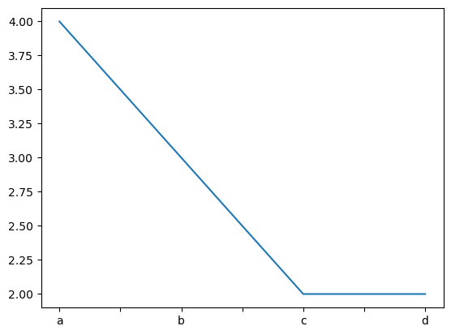

```python
s.plot.line()
```

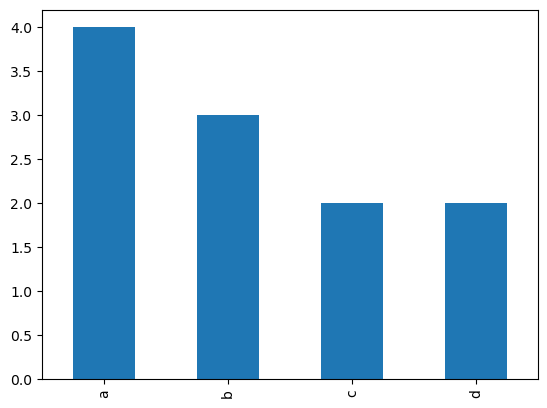

```python
s.plot.bar()
```

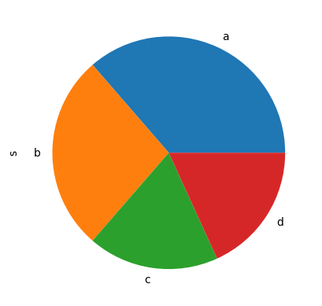

```python
s.plot.pie()
```

```python
v = pd.Series([1.1, 2.2, 3.1, 4.1], name='v')
```

The plot types can be configured by using `mpl` consistent input parameters which is covered in the next tutorial.

### Datetime and TimeDelta

In `pandas` date and time intervals are based upon the datatypes `datetime64` or `timedelta64` from the `numpy` library:

The `datetime64` class is normally initialised using a timestamp string of the following format:

```
np.datetime64('YYYY-MM-DD')
np.datetime64('YYYY-MM-DDThh:mm:ss:μμμμμμ')
```

For example:

```python
np.datetime64('2008-03-12')
```

```
numpy.datetime64('2008-03-12')
```

```python
np.datetime64('2008-03-12T14:30:15.123456')
```

```
numpy.datetime64('2008-03-12T14:30:15.123456')
```

The `timedelta64` is normally initialised using a set of tuples where `X` is the quantity followed by the unit:

[output not shown]

These are usually combined using addition:

```python
np.timedelta64(1, 'D') + np.timedelta64(1, 'h') + np.timedelta64(1, 's') + np.timedelta64(1, 'ms')
```

```
numpy.timedelta64(90001001,'ms')
```

These can be used to make an `Index` or `Series` respectively, using the `np.arange` function:

```python
start_time = np.datetime64('2008-03-12')
end_time = np.datetime64('2008-03-13')
time_interval = np.timedelta64(1, 'h')
```

```python
np.arange(start_time, end_time, time_interval)
```

```
array(['2008-03-12T00', '2008-03-12T01', '2008-03-12T02', '2008-03-12T03',
       '2008-03-12T04', '2008-03-12T05', '2008-03-12T06', '2008-03-12T07',
       '2008-03-12T08', '2008-03-12T09', '2008-03-12T10', '2008-03-12T11',
       '2008-03-12T12', '2008-03-12T13', '2008-03-12T14', '2008-03-12T15',
       '2008-03-12T16', '2008-03-12T17', '2008-03-12T18', '2008-03-12T19',
       '2008-03-12T20', '2008-03-12T21', '2008-03-12T22', '2008-03-12T23'],
      dtype='datetime64[h]')
```

These times can be cast into a `pd.Index` instance:

```python
pd.Index(np.arange(start_time, end_time, time_interval))
```

```
DatetimeIndex(['2008-03-12 00:00:00', '2008-03-12 01:00:00',
               '2008-03-12 02:00:00', '2008-03-12 03:00:00',
               '2008-03-12 04:00:00', '2008-03-12 05:00:00',
               '2008-03-12 06:00:00', '2008-03-12 07:00:00',
               '2008-03-12 08:00:00', '2008-03-12 09:00:00',
               '2008-03-12 10:00:00', '2008-03-12 11:00:00',
               '2008-03-12 12:00:00', '2008-03-12 13:00:00',
               '2008-03-12 14:00:00', '2008-03-12 15:00:00',
               '2008-03-12 16:00:00', '2008-03-12 17:00:00',
               '2008-03-12 18:00:00', '2008-03-12 19:00:00',
               '2008-03-12 20:00:00', '2008-03-12 21:00:00',
               '2008-03-12 22:00:00', '2008-03-12 23:00:00'],
              dtype='datetime64[s]', freq=None)
```

Or `pd.Series` instance:

```python
pd.Series(np.arange(start_time, end_time, time_interval), name='times')
```

```
0    2008-03-12 00:00:00
1    2008-03-12 01:00:00
2    2008-03-12 02:00:00
3    2008-03-12 03:00:00
4    2008-03-12 04:00:00
5    2008-03-12 05:00:00
6    2008-03-12 06:00:00
7    2008-03-12 07:00:00
8    2008-03-12 08:00:00
9    2008-03-12 09:00:00
10   2008-03-12 10:00:00
11   2008-03-12 11:00:00
12   2008-03-12 12:00:00
13   2008-03-12 13:00:00
14   2008-03-12 14:00:00
15   2008-03-12 15:00:00
16   2008-03-12 16:00:00
17   2008-03-12 17:00:00
18   2008-03-12 18:00:00
19   2008-03-12 19:00:00
20   2008-03-12 20:00:00
21   2008-03-12 21:00:00
22   2008-03-12 22:00:00
23   2008-03-12 23:00:00
Name: times, dtype: datetime64[s]
```

It is more common to have a `pd.Index` of times for example when recording a number of observations at a given time:

```python
times = pd.Index(np.arange(start_time, end_time, time_interval), name='times')
```

```python
times
```

```
DatetimeIndex(['2008-03-12 00:00:00', '2008-03-12 01:00:00',
               '2008-03-12 02:00:00', '2008-03-12 03:00:00',
               '2008-03-12 04:00:00', '2008-03-12 05:00:00',
               '2008-03-12 06:00:00', '2008-03-12 07:00:00',
               '2008-03-12 08:00:00', '2008-03-12 09:00:00',
               '2008-03-12 10:00:00', '2008-03-12 11:00:00',
               '2008-03-12 12:00:00', '2008-03-12 13:00:00',
               '2008-03-12 14:00:00', '2008-03-12 15:00:00',
               '2008-03-12 16:00:00', '2008-03-12 17:00:00',
               '2008-03-12 18:00:00', '2008-03-12 19:00:00',
               '2008-03-12 20:00:00', '2008-03-12 21:00:00',
               '2008-03-12 22:00:00', '2008-03-12 23:00:00'],
              dtype='datetime64[s]', name='times', freq=None)
```

The `Index` method `tz_localize` can be used to specify a timezone `tz` when timezone information has been omitted For example if these observations took place in Australia:

```python
times.tz_localize(tz='Australia/Sydney')
```

```
DatetimeIndex(['2008-03-12 00:00:00+11:00', '2008-03-12 01:00:00+11:00',
               '2008-03-12 02:00:00+11:00', '2008-03-12 03:00:00+11:00',
               '2008-03-12 04:00:00+11:00', '2008-03-12 05:00:00+11:00',
               '2008-03-12 06:00:00+11:00', '2008-03-12 07:00:00+11:00',
               '2008-03-12 08:00:00+11:00', '2008-03-12 09:00:00+11:00',
               '2008-03-12 10:00:00+11:00', '2008-03-12 11:00:00+11:00',
               '2008-03-12 12:00:00+11:00', '2008-03-12 13:00:00+11:00',
               '2008-03-12 14:00:00+11:00', '2008-03-12 15:00:00+11:00',
               '2008-03-12 16:00:00+11:00', '2008-03-12 17:00:00+11:00',
               '2008-03-12 18:00:00+11:00', '2008-03-12 19:00:00+11:00',
               '2008-03-12 20:00:00+11:00', '2008-03-12 21:00:00+11:00',
               '2008-03-12 22:00:00+11:00', '2008-03-12 23:00:00+11:00'],
              dtype='datetime64[s, Australia/Sydney]', name='times', freq=None)
```

The associated method `tz_convert` can be used to convert these times into corresponding times in another timezone:

```python
times.tz_localize(tz='Australia/Sydney').tz_convert(tz='Europe/London')
```

```
DatetimeIndex(['2008-03-11 13:00:00+00:00', '2008-03-11 14:00:00+00:00',
               '2008-03-11 15:00:00+00:00', '2008-03-11 16:00:00+00:00',
               '2008-03-11 17:00:00+00:00', '2008-03-11 18:00:00+00:00',
               '2008-03-11 19:00:00+00:00', '2008-03-11 20:00:00+00:00',
               '2008-03-11 21:00:00+00:00', '2008-03-11 22:00:00+00:00',
               '2008-03-11 23:00:00+00:00', '2008-03-12 00:00:00+00:00',
               '2008-03-12 01:00:00+00:00', '2008-03-12 02:00:00+00:00',
               '2008-03-12 03:00:00+00:00', '2008-03-12 04:00:00+00:00',
               '2008-03-12 05:00:00+00:00', '2008-03-12 06:00:00+00:00',
               '2008-03-12 07:00:00+00:00', '2008-03-12 08:00:00+00:00',
               '2008-03-12 09:00:00+00:00', '2008-03-12 10:00:00+00:00',
               '2008-03-12 11:00:00+00:00', '2008-03-12 12:00:00+00:00'],
              dtype='datetime64[s, Europe/London]', name='times', freq=None)
```

Unlike `np` which is timezone agnostic, `pd` can perform calculations involving `datetime64` data with a timezone:

```python
times.tz_localize(tz='Australia/Sydney')
```

```
DatetimeIndex(['2008-03-12 00:00:00+11:00', '2008-03-12 01:00:00+11:00',
               '2008-03-12 02:00:00+11:00', '2008-03-12 03:00:00+11:00',
               '2008-03-12 04:00:00+11:00', '2008-03-12 05:00:00+11:00',
               '2008-03-12 06:00:00+11:00', '2008-03-12 07:00:00+11:00',
               '2008-03-12 08:00:00+11:00', '2008-03-12 09:00:00+11:00',
               '2008-03-12 10:00:00+11:00', '2008-03-12 11:00:00+11:00',
               '2008-03-12 12:00:00+11:00', '2008-03-12 13:00:00+11:00',
               '2008-03-12 14:00:00+11:00', '2008-03-12 15:00:00+11:00',
               '2008-03-12 16:00:00+11:00', '2008-03-12 17:00:00+11:00',
               '2008-03-12 18:00:00+11:00', '2008-03-12 19:00:00+11:00',
               '2008-03-12 20:00:00+11:00', '2008-03-12 21:00:00+11:00',
               '2008-03-12 22:00:00+11:00', '2008-03-12 23:00:00+11:00'],
              dtype='datetime64[s, Australia/Sydney]', name='times', freq=None)
```

```python
times.tz_localize(tz='Australia/Sydney') + np.timedelta64(1, 'h')
```

```
DatetimeIndex(['2008-03-12 01:00:00+11:00', '2008-03-12 02:00:00+11:00',
               '2008-03-12 03:00:00+11:00', '2008-03-12 04:00:00+11:00',
               '2008-03-12 05:00:00+11:00', '2008-03-12 06:00:00+11:00',
               '2008-03-12 07:00:00+11:00', '2008-03-12 08:00:00+11:00',
               '2008-03-12 09:00:00+11:00', '2008-03-12 10:00:00+11:00',
               '2008-03-12 11:00:00+11:00', '2008-03-12 12:00:00+11:00',
               '2008-03-12 13:00:00+11:00', '2008-03-12 14:00:00+11:00',
               '2008-03-12 15:00:00+11:00', '2008-03-12 16:00:00+11:00',
               '2008-03-12 17:00:00+11:00', '2008-03-12 18:00:00+11:00',
               '2008-03-12 19:00:00+11:00', '2008-03-12 20:00:00+11:00',
               '2008-03-12 21:00:00+11:00', '2008-03-12 22:00:00+11:00',
               '2008-03-12 23:00:00+11:00', '2008-03-13 00:00:00+11:00'],
              dtype='datetime64[s, Australia/Sydney]', name='times', freq=None)
```

Care however needs to be taken as clock changes leads to ambiguous times. In the UK one of biannual clock changes for example can be examined:

```python
start_time = np.datetime64('2023-10-28T11:00:00')
end_time = np.datetime64('2023-10-29T03:00:00')
time_interval = np.timedelta64(30, 'm')
```

```python
times = pd.Index(np.arange(start_time, end_time, time_interval))
```

```python
times
```

```
DatetimeIndex(['2023-10-28 11:00:00', '2023-10-28 11:30:00',
               '2023-10-28 12:00:00', '2023-10-28 12:30:00',
               '2023-10-28 13:00:00', '2023-10-28 13:30:00',
               '2023-10-28 14:00:00', '2023-10-28 14:30:00',
               '2023-10-28 15:00:00', '2023-10-28 15:30:00',
               '2023-10-28 16:00:00', '2023-10-28 16:30:00',
               '2023-10-28 17:00:00', '2023-10-28 17:30:00',
               '2023-10-28 18:00:00', '2023-10-28 18:30:00',
               '2023-10-28 19:00:00', '2023-10-28 19:30:00',
               '2023-10-28 20:00:00', '2023-10-28 20:30:00',
               '2023-10-28 21:00:00', '2023-10-28 21:30:00',
               '2023-10-28 22:00:00', '2023-10-28 22:30:00',
               '2023-10-28 23:00:00', '2023-10-28 23:30:00',
               '2023-10-29 00:00:00', '2023-10-29 00:30:00',
               '2023-10-29 01:00:00', '2023-10-29 01:30:00',
               '2023-10-29 02:00:00', '2023-10-29 02:30:00'],
              dtype='datetime64[s]', freq=None)
```

When these recorded times are localised as UK times, the `tz_localize` method does not know what one of the two duplicate times this is i.e whether these time recorded occured before or after the clock change:

```python
times.tz_localize(tz='Europe/London', ambiguous='NaT')
```

```
DatetimeIndex(['2023-10-28 11:00:00+01:00', '2023-10-28 11:30:00+01:00',
               '2023-10-28 12:00:00+01:00', '2023-10-28 12:30:00+01:00',
               '2023-10-28 13:00:00+01:00', '2023-10-28 13:30:00+01:00',
               '2023-10-28 14:00:00+01:00', '2023-10-28 14:30:00+01:00',
               '2023-10-28 15:00:00+01:00', '2023-10-28 15:30:00+01:00',
               '2023-10-28 16:00:00+01:00', '2023-10-28 16:30:00+01:00',
               '2023-10-28 17:00:00+01:00', '2023-10-28 17:30:00+01:00',
               '2023-10-28 18:00:00+01:00', '2023-10-28 18:30:00+01:00',
               '2023-10-28 19:00:00+01:00', '2023-10-28 19:30:00+01:00',
               '2023-10-28 20:00:00+01:00', '2023-10-28 20:30:00+01:00',
               '2023-10-28 21:00:00+01:00', '2023-10-28 21:30:00+01:00',
               '2023-10-28 22:00:00+01:00', '2023-10-28 22:30:00+01:00',
               '2023-10-28 23:00:00+01:00', '2023-10-28 23:30:00+01:00',
               '2023-10-29 00:00:00+01:00', '2023-10-29 00:30:00+01:00',
                                     'NaT',                       'NaT',
               '2023-10-29 02:00:00+00:00', '2023-10-29 02:30:00+00:00'],
              dtype='datetime64[s, Europe/London]', freq=None)
```

In this case, casting to a `pd.Series` and using the `pd.Serie` method `interpolate` with the `'linear'` works because the `np.arange` function was used which works linearly:

```python
pd.Series(times.tz_localize(tz='Europe/London', ambiguous='NaT')).interpolate('linear')
```

```
0    2023-10-28 11:00:00+01:00
1    2023-10-28 11:30:00+01:00
2    2023-10-28 12:00:00+01:00
3    2023-10-28 12:30:00+01:00
4    2023-10-28 13:00:00+01:00
5    2023-10-28 13:30:00+01:00
6    2023-10-28 14:00:00+01:00
7    2023-10-28 14:30:00+01:00
8    2023-10-28 15:00:00+01:00
9    2023-10-28 15:30:00+01:00
10   2023-10-28 16:00:00+01:00
11   2023-10-28 16:30:00+01:00
12   2023-10-28 17:00:00+01:00
13   2023-10-28 17:30:00+01:00
14   2023-10-28 18:00:00+01:00
```

[output cut: 18 more lines]

## DataFrame Identifiers

The identifiers for a `pd.DataFrame` are:

```python
dir2(pd.DataFrame, drop_internal=True, exclude_identifier_list=obsolete.df_depreciation)
```

```
{'attribute': ['at',
               'attrs',
               'axes',
               'columns',
               'dtypes',
               'empty',
               'flags',
               'iat',
               'iloc',
               'index',
               'loc',
               'ndim',
               'shape',
               'size',
               'style',
               'values'],
 'constant': ['T'],
 'method': ['abs',
            'add',
            'add_prefix',
            'add_suffix',
            'agg',
            'aggregate',
            'align',
            'all',
            'any',
            'apply',
            'asfreq',
            'asof',
            'assign',
            'astype',
            'at_time',
            'backfill',
            'between_time',
            'bfill',
            'boxplot',
            'clip',
            'combine',
            'combine_first',
            'compare',
```

[output cut: 234 more lines]

```
                      '__ror__',
                      '__round__',
                      '__rpow__',
                      '__rsub__',
                      '__rtruediv__',
                      '__rxor__',
                      '__setattr__',
                      '__setitem__',
                      '__setstate__',
                      '__sizeof__',
                      '__str__',
                      '__sub__',
                      '__subclasshook__',
                      '__truediv__',
                      '__xor__']}
```

The initialisation signature for a `pd.DataFrame` can be examined:

```python
pd.DataFrame?
```

```
Init signature:
pd.DataFrame(
    data=None,
    index: 'Axes | None' = None,
    columns: 'Axes | None' = None,
    dtype: 'Dtype | None' = None,
    copy: 'bool | None' = None,
) -> 'None'
Docstring:
Two-dimensional, size-mutable, potentially heterogeneous tabular data.

Data structure also contains labeled axes (rows and columns).
Arithmetic operations align on both row and column labels. Can be
thought of as a dict-like container for Series objects. The primary
pandas data structure.

Parameters
----------
data : ndarray (structured or homogeneous), Iterable, dict, or DataFrame
    Dict can contain Series, arrays, constants, dataclass or list-like objects. If
    data is a dict, column order follows insertion-order. If a dict contains Series
    which have an index defined, it is aligned by its index. This alignment also
    occurs if data is a Series or a DataFrame itself. Alignment is done on
    Series/DataFrame inputs.

    If data is a list of dicts, column order follows insertion-order.

index : Index or array-like
    Index to use for resulting frame. Will default to RangeIndex if
    no indexing information part of input data and no index provided.
columns : Index or array-like
    Column labels to use for resulting frame when data does not have them,
    defaulting to RangeIndex(0, 1, 2, ..., n). If data contains column labels,
    will perform column selection instead.
dtype : dtype, default None
    Data type to force. Only a single dtype is allowed. If None, infer.
copy : bool or None, default None
    Copy data from inputs.
    For dict data, the default of None behaves like ``copy=True``.  For DataFrame
    or 2d ndarray input, the default of None behaves like ``copy=False``.
```

[output cut: 88 more lines]

```
>>> df = pd.DataFrame(data=ser, index=["a", "c"])
>>> df
   0
a  1
c  3

>>> df1 = pd.DataFrame([1, 2, 3], index=["a", "b", "c"], columns=["x"])
>>> df2 = pd.DataFrame(data=df1, index=["a", "c"])
>>> df2
   x
a  1
c  3
File:           c:\users\phili\anaconda3\envs\vscode-env\lib\site-packages\pandas\core\frame.py
Type:           type
Subclasses:     SubclassedDataFrame
```

A `pd.DataFrame` can be instantiated by supplying `data` to a `dict` where each `key` is the `pd.Series` `name` and `pd.Series` `values` respectively:

```python
df1 = pd.DataFrame({'w': [0, 1, 2, 3],
                    'x': [4, 5, 6, 7],
                    'y': [8, 9, 10, 11],
                    'z': [12, 13, 14, 15]})
```

```python
df1
```

|  | w | x | y | z |
| --- | --- | --- | --- | --- |
| 0 | 0 | 4 | 8 | 12 |
| 1 | 1 | 5 | 9 | 13 |
| 2 | 2 | 6 | 10 | 14 |
| 3 | 3 | 7 | 11 | 15 |

### Attributes

A `pd.DataFrame` instance has 2 dimensions so `ndim` is:

```python
df1.ndim
```

```
2
```

The attribute `axes` displays a list of each axis:

```python
df1.axes
```

```
[RangeIndex(start=0, stop=4, step=1),
 Index(['w', 'x', 'y', 'z'], dtype='object')]
```

The detail for each axis can be viewed:

```python
df1.index
```

```
RangeIndex(start=0, stop=4, step=1)
```

Note the `columns` axis is an `Index` instance. The `dtype` is `'O'` because it contains `str` instances:

```python
df1.columns
```

```
Index(['w', 'x', 'y', 'z'], dtype='object')
```

`dtypes` groups the datatype for each `pd.Series` in the `pd.DataFrame`, note that this is a `pd.Series` instance:

```python
df1.dtypes
```

```
w    int64
x    int64
y    int64
z    int64
dtype: object
```

The `pd.DataFrame` instance also has a `shape` and `size`:

```python
df1.shape
```

```
(4, 4)
```

```python
df1.size
```

```
16
```

The `pd.DataFrame` instance has an optional attribute `attrs` which is an empty `dict` by default:

```python
df1.attrs
```

```
{}
```

This is used to provive a description and a reference for example:

```python
df1.attrs = {'description': 'This is a DataFrame',
            'documentation': 'https://pandas.pydata.org/'}
```

```python
df1.attrs
```

```
{'description': 'This is a DataFrame',
 'documentation': 'https://pandas.pydata.org/'}
```

The `pd.DataFrame` attribute `style` will display a styled `DataFrame` in the cell output:

```python
df1.style
```

|  | w | x | y | z |
| --- | --- | --- | --- | --- |
| 0 | 0 | 4 | 8 | 12 |
| 1 | 1 | 5 | 9 | 13 |
| 2 | 2 | 6 | 10 | 14 |
| 3 | 3 | 7 | 11 | 15 |

A number of identifiers are available to be called from `style` to change how the `pd.DataFrame` instance displays:

```python
dir2(df1.style, drop_internal=True)
```

```
{'attribute': ['caption',
               'cell_context',
               'cell_ids',
               'columns',
               'concatenated',
               'css',
               'ctx',
               'ctx_columns',
               'ctx_index',
               'data',
               'env',
               'hidden_columns',
               'hidden_rows',
               'hide_column_names',
               'hide_columns_',
               'hide_index_',
               'hide_index_names',
               'index',
               'loader',
               'table_attributes',
               'table_styles',
               'template_html',
               'template_html_style',
               'template_html_table',
               'template_latex',
               'template_string',
               'tooltips',
               'uuid',
               'uuid_len'],
 'method': ['apply',
            'apply_index',
            'applymap',
            'applymap_index',
            'background_gradient',
            'bar',
            'clear',
            'concat',
            'export',
            'format',
            'format_index',
```

[output cut: 36 more lines]

```
                      '__gt__',
                      '__hash__',
                      '__init__',
                      '__init_subclass__',
                      '__le__',
                      '__lt__',
                      '__ne__',
                      '__new__',
                      '__reduce__',
                      '__reduce_ex__',
                      '__repr__',
                      '__setattr__',
                      '__sizeof__',
                      '__str__',
                      '__subclasshook__']}
```

These can often be stacked:

```python
df1.style.format(precision=3).set_caption('DataFrame Instance').relabel_index(['a', 'b', 'c', 'd'])
```

DataFrame Instance

|  | w | x | y | z |
| --- | --- | --- | --- | --- |
| a | 0 | 4 | 8 | 12 |
| b | 1 | 5 | 9 | 13 |
| c | 2 | 6 | 10 | 14 |
| d | 3 | 7 | 11 | 15 |

### Indexing

```python
df1 = pd.DataFrame({'w': [0, 1, 2, 3],
                    'x': [4, 5, 6, 7],
                    'y': [8, 9, 10, 11],
                    'z': [12, 13, 14, 15]})
```

When each `pd.Series` `name` is a valid identifier:

```python
'w'.isidentifier()
```

```
True
```

It is available as an attribute:

```python
df1.w
```

```
0    0
1    1
2    2
3    3
Name: w, dtype: int64
```

A `pd.Series` can be indexed from a `pd.DataFrame` by using square brackets and the `str` instance correponding to the `pd.Series` `name`:

```python
df1['x']
```

```
0    4
1    5
2    6
3    7
Name: x, dtype: int64
```

A single value can be specified by indexing into the returned `pd.Series`:

```python
df1['x'][1]
```

```
5
```

The data supplied to the `df1` was a `dict` instance:

```python
mapping = {'w': [0, 1, 2, 3],
           'x': [4, 5, 6, 7],
           'y': [8, 9, 10, 11],
           'z': [12, 13, 14, 15]}
```

Notice the consistency by indexing into the `dict` using a `key`:

```python
mapping['x']
```

```
[4, 5, 6, 7]
```

And then indexing into that `list` to get a single element:

```python
mapping['x'][1]
```

```
5
```

A `list` of `str` instances can also be provided where each `str` corresponds to a `pd.Series` `name` returns a `pd.DataFrame` instance:

```python
df1[['x', 'z']]
```

|  | x | z |
| --- | --- | --- |
| 0 | 4 | 12 |
| 1 | 5 | 13 |
| 2 | 6 | 14 |
| 3 | 7 | 15 |

The `iloc` attribute is used to instead retrieve a row by specifying the numeric value in the `index`. The row is returned as a `pd.Series` and because the default representation for a `pd.Series` is a column, the row is displayed as a column:

```python
df1.iloc[2]
```

```
w     2
x     6
y    10
z    14
Name: 2, dtype: int64
```

Slicing can also be used to return a `pd.DataFrame` instance:

```python
df1.iloc[2:4]
```

|  | w | x | y | z |
| --- | --- | --- | --- | --- |
| 2 | 2 | 6 | 10 | 14 |
| 3 | 3 | 7 | 11 | 15 |

The `at` attribute is used to return a value, specifying the `index` `name` (when applicable) and the `column` `name`:

```python
df1.at[0, 'x']
```

```
4
```

If a second `pd.DataFrame` instance with a `pd.Index` that is named is used:

```python
df2 = pd.DataFrame({'w': [0, 1, 2, 3],
                    'x': [4, 5, 6, 7],
                    'y': [8, 9, 10, 11],
                    'z': [12, 13, 14, 15]},
                 index=('a', 'b', 'c', 'd'))
```

```python
df2
```

|  | w | x | y | z |
| --- | --- | --- | --- | --- |
| a | 0 | 4 | 8 | 12 |
| b | 1 | 5 | 9 | 13 |
| c | 2 | 6 | 10 | 14 |
| d | 3 | 7 | 11 | 15 |

The difference between indexing attributes can be examined such as indexing with a `column` `name`:

```python
df2['x']
```

```
a    4
b    5
c    6
d    7
Name: x, dtype: int64
```

```python
df2[['x', 'y']]
```

|  | x | y |
| --- | --- | --- |
| a | 4 | 8 |
| b | 5 | 9 |
| c | 6 | 10 |
| d | 7 | 11 |

Indexing a row using an `index` `name`:

```python
df2.loc['b']
```

```
w     1
x     5
y     9
z    13
Name: b, dtype: int64
```

Indexing a row using an `index` `int`:

```python
df2.iloc[1]
```

```
w     1
x     5
y     9
z    13
Name: b, dtype: int64
```

```python
df2.iloc[1:3]
```

|  | w | x | y | z |
| --- | --- | --- | --- | --- |
| b | 1 | 5 | 9 | 13 |
| c | 2 | 6 | 10 | 14 |

Indexing all rows and using a `column` `int`:

```python
df2.iloc[:, [0, 1]]
```

|  | w | x |
| --- | --- | --- |
| a | 0 | 4 |
| b | 1 | 5 |
| c | 2 | 6 |
| d | 3 | 7 |

Specifying an element using `at` and specifying a `row` `name` followed by a `column` `name`:

```python
df2.at['b', 'y']
```

```
9
```

Specifying an element using `iat` and specifying a `row` `int` followed by a `column` `int`:

```python
df2.iat[1, 2]
```

```
9
```

Under the hood `iloc` can be conceptualised as using a reset index:

```python
df2
```

|  | w | x | y | z |
| --- | --- | --- | --- | --- |
| a | 0 | 4 | 8 | 12 |
| b | 1 | 5 | 9 | 13 |
| c | 2 | 6 | 10 | 14 |
| d | 3 | 7 | 11 | 15 |

```python
df2.reset_index()
```

|  | index | w | x | y | z |
| --- | --- | --- | --- | --- | --- |
| 0 | a | 0 | 4 | 8 | 12 |
| 1 | b | 1 | 5 | 9 | 13 |
| 2 | c | 2 | 6 | 10 | 14 |
| 3 | d | 3 | 7 | 11 | 15 |

```python
df2.iloc[2]
```

```
w     2
x     6
y    10
z    14
Name: c, dtype: int64
```

Or by examining the underlying `np.ndarray` instance and indexing numerically:

```python
df2.values
```

```
array([[ 0,  4,  8, 12],
       [ 1,  5,  9, 13],
       [ 2,  6, 10, 14],
       [ 3,  7, 11, 15]], dtype=int64)
```

```python
df2.values[2]
```

```
array([ 2,  6, 10, 14], dtype=int64)
```

```python
df2.iloc[2, 1]
```

```
6
```

```python
df2.values[2, 1]
```

```
6
```

If `df1` is examined:

```python
df1
```

|  | w | x | y | z |
| --- | --- | --- | --- | --- |
| 0 | 0 | 4 | 8 | 12 |
| 1 | 1 | 5 | 9 | 13 |
| 2 | 2 | 6 | 10 | 14 |
| 3 | 3 | 7 | 11 | 15 |

Notice a `pd.Series` can be retrieved using the attribute or by indexing:

```python
df1.x
```

```
0    4
1    5
2    6
3    7
Name: x, dtype: int64
```

```python
df1['x']
```

```
0    4
1    5
2    6
3    7
Name: x, dtype: int64
```

Attempting to access an attribute that does not exist will flag up an `AttributeError`. Indexing using square brackets can be used to create a new `key` in a `dict` instance, the `key` then essentially becomes an instance name for the `value`:

```python
mapping['letters'] = ['A', 'B', 'C', 'D']
```

```python
mapping
```

```
{'w': [0, 1, 2, 3],
 'x': [4, 5, 6, 7],
 'y': [8, 9, 10, 11],
 'z': [12, 13, 14, 15],
 'letters': ['A', 'B', 'C', 'D']}
```

Similar syntax can be used for a `pd.DataFrame` instance:

```python
df1['letters'] = pd.Series(['A', 'B', 'C', 'D'], name='letters')
```

```python
df1
```

|  | w | x | y | z | letters |
| --- | --- | --- | --- | --- | --- |
| 0 | 0 | 4 | 8 | 12 | A |
| 1 | 1 | 5 | 9 | 13 | B |
| 2 | 2 | 6 | 10 | 14 | C |
| 3 | 3 | 7 | 11 | 15 | D |

Since the new `pd.Series` `name` is a valid identifier name, it becomes an attribute:

```python
df1.letters
```

```
0    A
1    B
2    C
3    D
Name: letters, dtype: object
```

### Information

The example `pd.DataFrame` instance `df3` is very small:

```python
df3 = pd.DataFrame({'w': [0, 1, 2, 3],
                    'x': [4, 5, None, 7],
                    'y': [8, None, 10, 11],
                    'z': [12, 13, 14, 15]})
```

```python
df3
```

|  | w | x | y | z |
| --- | --- | --- | --- | --- |
| 0 | 0 | 4.0 | 8.0 | 12 |
| 1 | 1 | 5.0 | NaN | 13 |
| 2 | 2 | NaN | 10.0 | 14 |
| 3 | 3 | 7.0 | 11.0 | 15 |

However many `pd.DataFrame` instance have hundreds of rows of data and a preview can be made using the `pd.DataFrame` method `head` or `tail`. These methods optionally take an `int` as a positional input argument, the `int` supplied gives the number of rows to show, this is typically `5` if unspecified:

```python
df3.head(2)
```

|  | w | x | y | z |
| --- | --- | --- | --- | --- |
| 0 | 0 | 4.0 | 8.0 | 12 |
| 1 | 1 | 5.0 | NaN | 13 |

```python
df3.tail(3)
```

|  | w | x | y | z |
| --- | --- | --- | --- | --- |
| 1 | 1 | 5.0 | NaN | 13 |
| 2 | 2 | NaN | 10.0 | 14 |
| 3 | 3 | 7.0 | 11.0 | 15 |

The `info` gives details about each `pd.Series` such as the `name` and number of non-null values as well as the `dtype`:

```python
df3.info()
```

```
<class 'pandas.core.frame.DataFrame'>
RangeIndex: 4 entries, 0 to 3
Data columns (total 4 columns):
 #   Column  Non-Null Count  Dtype
---  ------  --------------  -----
 0   w       4 non-null      int64
 1   x       3 non-null      float64
 2   y       3 non-null      float64
 3   z       4 non-null      int64
dtypes: float64(2), int64(2)
memory usage: 260.0 bytes
```

When a `pd.Series` is numeric, descriptive statistics can be computed on it:

```python
df3.describe()
```

|  | w | x | y | z |
| --- | --- | --- | --- | --- |
| count | 4.000000 | 3.000000 | 3.000000 | 4.000000 |
| mean | 1.500000 | 5.333333 | 9.666667 | 13.500000 |
| std | 1.290994 | 1.527525 | 1.527525 | 1.290994 |
| min | 0.000000 | 4.000000 | 8.000000 | 12.000000 |
| 25% | 0.750000 | 4.500000 | 9.000000 | 12.750000 |
| 50% | 1.500000 | 5.000000 | 10.000000 | 13.500000 |
| 75% | 2.250000 | 6.000000 | 10.500000 | 14.250000 |
| max | 3.000000 | 7.000000 | 11.000000 | 15.000000 |

If another `pd.DataFrame` instance is examined with some values that are `None`:

```python
df3 = pd.DataFrame({'w': [0, 1, 2, 3],
                    'x': [4, 5, None, 7],
                    'y': [8, None, 10, 11],
                    'z': [12, 13, 14, 15]})
```

Then the `pd.Series` with `None` are cast into `float64` instances and have a non-null count lower than the `size` of the `pd.Series`:

```python
df3.info()
```

```
<class 'pandas.core.frame.DataFrame'>
RangeIndex: 4 entries, 0 to 3
Data columns (total 4 columns):
 #   Column  Non-Null Count  Dtype
---  ------  --------------  -----
 0   w       4 non-null      int64
 1   x       3 non-null      float64
 2   y       3 non-null      float64
 3   z       4 non-null      int64
dtypes: float64(2), int64(2)
memory usage: 260.0 bytes
```

The `isna` (alias `isnull`) will return a `bool` `pd.DataFrame` instance:

```python
df3.isna()
```

|  | w | x | y | z |
| --- | --- | --- | --- | --- |
| 0 | False | False | False | False |
| 1 | False | False | True | False |
| 2 | False | True | False | False |
| 3 | False | False | False | False |

```python
df3.isna().any()
```

```
w    False
x     True
y     True
z    False
dtype: bool
```

This can be used to see what `pd.Series` instances need to be examined to remove or fill in missing values.

The `notna` (alias `notnull`) will return the inverted `bool` `pd.DataFrame` instance:

```python
df3.notna()
```

|  | w | x | y | z |
| --- | --- | --- | --- | --- |
| 0 | True | True | True | True |
| 1 | True | True | False | True |
| 2 | True | False | True | True |
| 3 | True | True | True | True |

### Mutability

The three classes are mutable and therefore the `__hash__` identifier is `None`:

```python
pd.Index.__hash__ == None
```

```
True
```

```python
pd.Series.__hash__ == None
```

```
True
```

```python
pd.DataFrame.__hash__ == None
```

```
True
```

```python
np.ndarray.__hash__ == None
```

```
True
```

Most of the methods are immutable by default, returning a new instance. A large number of `pd.Series` and consistent `pd.DataFrame` methods have the parameter `inplace` which can be used to change whether the method is immutable or mutable:

```python
dir2(pd.Series, parameter='inplace', exclude_identifier_list=obsolete.series_depreciation)
```

```
{'method': ['bfill',
            'clip',
            'drop',
            'drop_duplicates',
            'dropna',
            'ffill',
            'fillna',
            'interpolate',
            'mask',
            'pad',
            'rename',
            'rename_axis',
            'replace',
            'reset_index',
            'sort_index',
            'sort_values',
            'where']}
```

For example the `pd.DataFrame` instance `df3` can be examined:

```python
df3
```

|  | w | x | y | z |
| --- | --- | --- | --- | --- |
| 0 | 0 | 4.0 | 8.0 | 12 |
| 1 | 1 | 5.0 | NaN | 13 |
| 2 | 2 | NaN | 10.0 | 14 |
| 3 | 3 | 7.0 | 11.0 | 15 |

Notice that `x` has a `NaN` value (`np.nan` instance):

```python
df3['x']
```

```
0    4.0
1    5.0
2    NaN
3    7.0
Name: x, dtype: float64
```

The method `fillna` can be used to fill in a missing value using a specified value:

```python
df3['x'].fillna(0) # immutable returns a new pd.Series
```

```
0    4.0
1    5.0
2    0.0
3    7.0
Name: x, dtype: float64
```

```python
df3['x'].bfill() # immutable returns a new pd.Series
```

```
0    4.0
1    5.0
2    7.0
3    7.0
Name: x, dtype: float64
```

The method `ffill` can be used to fill in a missing value using the previous value:

```python
df3['x'].ffill() # immutable returns a new pd.Series
```

```
0    4.0
1    5.0
2    5.0
3    7.0
Name: x, dtype: float64
```

The method `interpolate` can be used to interpolate values using `'linear'`, `'quadratic'` or `'cubic'` (there is not enough data for `'cubic'` in this sample) interpolation:

```python
df3['x'].interpolate('linear') # immutable returns a new pd.Series
```

```
0    4.0
1    5.0
2    6.0
3    7.0
Name: x, dtype: float64
```

```python
df3['x'].interpolate('quadratic') # immutable returns a new pd.Series
```

```
0    4.0
1    5.0
2    6.0
3    7.0
Name: x, dtype: float64
```

Notice that the `df3` is unchanged:

```python
df3 # not updated
```

|  | w | x | y | z |
| --- | --- | --- | --- | --- |
| 0 | 0 | 4.0 | 8.0 | 12 |
| 1 | 1 | 5.0 | NaN | 13 |
| 2 | 2 | NaN | 10.0 | 14 |
| 3 | 3 | 7.0 | 11.0 | 15 |

When the named parameter `inplace` is set to a `bool` value of `True`, the method become mutable and updates the `pd.Series` with name `'x'` found on the `pd.DataFrame` instance `df3` inplace:

```python
df3['x'].ffill(inplace=True) # mutable no return value
```

```python
df3 # updated in place
```

|  | w | x | y | z |
| --- | --- | --- | --- | --- |
| 0 | 0 | 4.0 | 8.0 | 12 |
| 1 | 1 | 5.0 | NaN | 13 |
| 2 | 2 | 5.0 | 10.0 | 14 |
| 3 | 3 | 7.0 | 11.0 | 15 |

A mutable method should not be used with reassignment because it has no return value and the value attempted to be reassigned is therefore `None`:

```
df3['y'] = df3['y'].ffill(inplace=True)
```

The above attempts to use a mutable method which returns the value `None` and then it attempts to reassign `None` to the `pd.Series` instance with `name` `df3['y']`.

This is one of the most common mistakes beginners make, currently the operation is carried out with a `FutureWarning` however this behaviour will be prevented in pandas 3.

Because the `pd.Index`, `pd.Series` and `pd.DataFrame` are mutable an item can be accessed:

```python
df3.at[1, 'y']
```

```
nan
```

And reassigned:

```python
df3.at[1, 'y'] = 40
```

```python
df3
```

|  | w | x | y | z |
| --- | --- | --- | --- | --- |
| 0 | 0 | 4.0 | 8.0 | 12 |
| 1 | 1 | 5.0 | 40.0 | 13 |
| 2 | 2 | 5.0 | 10.0 | 14 |
| 3 | 3 | 7.0 | 11.0 | 15 |

The `del` keyword only works for deleting a `pd.Series` from a `pd.DataFrame`:

```python
del df3['y']
```

```python
df3
```

|  | w | x | z |
| --- | --- | --- | --- |
| 0 | 0 | 4.0 | 12 |
| 1 | 1 | 5.0 | 13 |
| 2 | 2 | 5.0 | 14 |
| 3 | 3 | 7.0 | 15 |

The `pd.DataFrame` has mutable methods consistent with a mutable `Collection` such as a `list`. `insert` can be used to insert a new `pd.Series` at a specified index:

```python
df3.insert(loc=2, column='y2', value=[20, 21, 22, 23])
```

```python
df3
```

|  | w | x | y2 | z |
| --- | --- | --- | --- | --- |
| 0 | 0 | 4.0 | 20 | 12 |
| 1 | 1 | 5.0 | 21 | 13 |
| 2 | 2 | 5.0 | 22 | 14 |
| 3 | 3 | 7.0 | 23 | 15 |

`pop` can be used to `pop` of a `pd.Series` using a `str` instance that corresponds to the the `pd.Series` `name`. Recall that `pop` is one of the few mutable methods that has a `return` value. The `return` value is the `pd.Series` popped and the `pd.DataFrame` instance is mutated inplace:

```python
df3.pop('z') # mutable method WITH return value of pd.Series
```

```
0    12
1    13
2    14
3    15
Name: z, dtype: int64
```

```python
df3 # mutated inplace
```

|  | w | x | y2 |
| --- | --- | --- | --- |
| 0 | 0 | 4.0 | 20 |
| 1 | 1 | 5.0 | 21 |
| 2 | 2 | 5.0 | 22 |
| 3 | 3 | 7.0 | 23 |

Note there is no `append` method because indexing with a new `pd.Series` name appends the `pd.Series` to the end of the `pd.DataFrame`:

```python
df3['z2'] = pd.Series([30, 31, 32, 33], name='z')
```

Restoring `df3` to the following:

```python
df3 = pd.DataFrame({'w': [0, 1, 2, 3],
                    'x': [4, 5, None, 7],
                    'y': [8, None, 10, 11],
                    'z': [12, 13, 14, 15]})
```

The `pd.DataFrame` method `dropna` can be used. Notice any observations with a `NaN` (`None` or `np.nan`) datatype are dropped:

```python
df3.dropna()
```

|  | w | x | y | z |
| --- | --- | --- | --- | --- |
| 0 | 0 | 4.0 | 8.0 | 12 |
| 3 | 3 | 7.0 | 11.0 | 15 |

Alternatively an observation can be dropped using:

```python
df3.drop(0)
```

|  | w | x | y | z |
| --- | --- | --- | --- | --- |
| 1 | 1 | 5.0 | NaN | 13 |
| 2 | 2 | NaN | 10.0 | 14 |
| 3 | 3 | 7.0 | 11.0 | 15 |

```python
df3.drop([0, 3])
```

|  | w | x | y | z |
| --- | --- | --- | --- | --- |
| 1 | 1 | 5.0 | NaN | 13 |
| 2 | 2 | NaN | 10.0 | 14 |

If the following `pd.DataFrame` instance is instantiated:

```python
df4 = pd.DataFrame({'w': [0, 0, 4, 4],
                    'x': [1, 1, 5, 5],
                    'y': [2, 2, 6, 6],
                    'z': [3, 3, 7, 7]})
```

Notice index `0` and `1` have duplicate data and index `2` and `3` also have duplicate data:

```python
df4
```

|  | w | x | y | z |
| --- | --- | --- | --- | --- |
| 0 | 0 | 1 | 2 | 3 |
| 1 | 0 | 1 | 2 | 3 |
| 2 | 4 | 5 | 6 | 7 |
| 3 | 4 | 5 | 6 | 7 |

The duplicates can be dropped using:

```python
df4.drop_duplicates()
```

|  | w | x | y | z |
| --- | --- | --- | --- | --- |
| 0 | 0 | 1 | 2 | 3 |
| 2 | 4 | 5 | 6 | 7 |

The index is now `0` and `2` as the observations that were at position `1` and `3` on the `index` have been dropped. The index can be reset using the `reset_index` method:

```python
df4.drop_duplicates().reset_index()
```

|  | index | w | x | y | z |
| --- | --- | --- | --- | --- | --- |
| 0 | 0 | 0 | 1 | 2 | 3 |
| 1 | 2 | 4 | 5 | 6 | 7 |

The old `index` is now a `pd.Series` with `name` `'index'`, it can also be dropped:

```python
df4.drop_duplicates().reset_index(drop=True)
```

|  | w | x | y | z |
| --- | --- | --- | --- | --- |
| 0 | 0 | 1 | 2 | 3 |
| 1 | 4 | 5 | 6 | 7 |

If the `pd.DataFrame` instance `df4` is examined:

```python
df4
```

|  | w | x | y | z |
| --- | --- | --- | --- | --- |
| 0 | 0 | 1 | 2 | 3 |
| 1 | 0 | 1 | 2 | 3 |
| 2 | 4 | 5 | 6 | 7 |
| 3 | 4 | 5 | 6 | 7 |

Its `len` can be determined:

```python
len(df4)
```

```
4
```

Notice that this is `1` more than the last index. `loc` can be used to access this new value on the `index` and assign it to a `dict` instance that corresponds to data from a new observation:

```python
df4.loc[len(df4)] = {'w': 9, 'x': 99, 'y': 999, 'z': 999}
```

```python
df4
```

|  | w | x | y | z |
| --- | --- | --- | --- | --- |
| 0 | 0 | 1 | 2 | 3 |
| 1 | 0 | 1 | 2 | 3 |
| 2 | 4 | 5 | 6 | 7 |
| 3 | 4 | 5 | 6 | 7 |
| 4 | 9 | 99 | 999 | 999 |

`iloc` cannot be used for this purpose as it cannot access a numeric index value that does not yet exist. Sometimes it is more convenient to provide a `list` of new values:

```python
df4.loc[len(df4)] = [8, 88, 888, 888]
```

```python
df4
```

|  | w | x | y | z |
| --- | --- | --- | --- | --- |
| 0 | 0 | 1 | 2 | 3 |
| 1 | 0 | 1 | 2 | 3 |
| 2 | 4 | 5 | 6 | 7 |
| 3 | 4 | 5 | 6 | 7 |
| 4 | 9 | 99 | 999 | 999 |
| 5 | 8 | 88 | 888 | 888 |

If the following `pd.DataFrame` instance is instantiated:

```python
df5 = pd.DataFrame({'w': [2, 2, 1, 1],
                    'x': [3, 3, 3, 4],
                    'y': [5, 6, 8, 8],
                    'z': ['a', 'b', 'c', 'd']})
```

```python
df5
```

|  | w | x | y | z |
| --- | --- | --- | --- | --- |
| 0 | 2 | 3 | 5 | a |
| 1 | 2 | 3 | 6 | b |
| 2 | 1 | 3 | 8 | c |
| 3 | 1 | 4 | 8 | d |

The values in a `pd.DataFrame` can be sorted using the `sort_values` method and providing a `list` of `str` instances that each correspond to a name of a `pd.Series` to sort by:

```python
df5.sort_values(by=['w', 'x', 'y'], inplace=True) # mutable
```

```python
df5 # modified inplace
```

|  | w | x | y | z |
| --- | --- | --- | --- | --- |
| 2 | 1 | 3 | 8 | c |
| 3 | 1 | 4 | 8 | d |
| 0 | 2 | 3 | 5 | a |
| 1 | 2 | 3 | 6 | b |

The `pd.DataFrame` method can alternatively be used to sort by the values of the `index` which restores the original `df5`:

```python
df5.sort_index() # return value
```

|  | w | x | y | z |
| --- | --- | --- | --- | --- |
| 0 | 2 | 3 | 5 | a |
| 1 | 2 | 3 | 6 | b |
| 2 | 1 | 3 | 8 | c |
| 3 | 1 | 4 | 8 | d |

```python
df5 # not modified
```

|  | w | x | y | z |
| --- | --- | --- | --- | --- |
| 2 | 1 | 3 | 8 | c |
| 3 | 1 | 4 | 8 | d |
| 0 | 2 | 3 | 5 | a |
| 1 | 2 | 3 | 6 | b |

The `index` is often reset after sorting:

```python
df5.reset_index(drop=True)
```

|  | w | x | y | z |
| --- | --- | --- | --- | --- |
| 0 | 1 | 3 | 8 | c |
| 1 | 1 | 4 | 8 | d |
| 2 | 2 | 3 | 5 | a |
| 3 | 2 | 3 | 6 | b |

If two `pd.DataFrame` instances have the same `index` but different `pd.Series`, they can be joined using the `join` method:

```python
dfleft = pd.DataFrame({'w1': [1, 2, 3, 4],
                      'x1': [1, 2, 3, 4],
                      'y1': [1, 2, 3, 4],
                      'z1': [1, 2, 3, 4]})
dfright = pd.DataFrame({'w2': [5, 6, 7, 8],
                        'x2': [5, 6, 7, 8],
                        'y2': [5, 6, 7, 8]})
```

```python
dfleft.join(dfright)
```

|  | w1 | x1 | y1 | z1 | w2 | x2 | y2 |
| --- | --- | --- | --- | --- | --- | --- | --- |
| 0 | 1 | 1 | 1 | 1 | 5 | 5 | 5 |
| 1 | 2 | 2 | 2 | 2 | 6 | 6 | 6 |
| 2 | 3 | 3 | 3 | 3 | 7 | 7 | 7 |
| 3 | 4 | 4 | 4 | 4 | 8 | 8 | 8 |

If two `pd.DataFrame` instances have the same `pd.Series` but different observations, they can be concatenated using the `pd.concat` function:

```python
dftop = pd.DataFrame({'w': [1, 2, 3, 4],
                      'x': [1, 2, 3, 4],
                      'y': [1, 2, 3, 4],
                      'z': [1, 2, 3, 4]})
dfbot = pd.DataFrame({'w': [5, 6, 7, 8],
                      'x': [5, 6, 7, 8],
                      'y': [5, 6, 7, 8],
                      'z': [5, 6, 7, 8]})
```

```python
pd.concat([dftop, dfbot])
```

|  | w | x | y | z |
| --- | --- | --- | --- | --- |
| 0 | 1 | 1 | 1 | 1 |
| 1 | 2 | 2 | 2 | 2 |
| 2 | 3 | 3 | 3 | 3 |
| 3 | 4 | 4 | 4 | 4 |
| 0 | 5 | 5 | 5 | 5 |
| 1 | 6 | 6 | 6 | 6 |
| 2 | 7 | 7 | 7 | 7 |
| 3 | 8 | 8 | 8 | 8 |

This outputs a new `pd.DataFrame` instance. Note there are now two observations with the `int` value `0` on the index:

```python
pd.concat([dftop, dfbot]).loc[0]
```

|  | w | x | y | z |
| --- | --- | --- | --- | --- |
| 0 | 1 | 1 | 1 | 1 |
| 0 | 5 | 5 | 5 | 5 |

To rectify this, the named parameter `ignore_index` can be assigned to the `bool` instance `True`:

```python
pd.concat([dftop, dfbot], ignore_index=True)
```

|  | w | x | y | z |
| --- | --- | --- | --- | --- |
| 0 | 1 | 1 | 1 | 1 |
| 1 | 2 | 2 | 2 | 2 |
| 2 | 3 | 3 | 3 | 3 |
| 3 | 4 | 4 | 4 | 4 |
| 4 | 5 | 5 | 5 | 5 |
| 5 | 6 | 6 | 6 | 6 |
| 6 | 7 | 7 | 7 | 7 |
| 7 | 8 | 8 | 8 | 8 |

The `pd.DataFrame` method `align` is used for aligning two `pd.DataFrame` instances side by side within a `tuple`:

```python
dfa = pd.DataFrame({'x': [1, 2],
                    'y': [5, 6],
                    'z': [1, 2]})
dfb = pd.DataFrame({'w': [5, 6, 7, 8],
                    'x': [5, 6, 7, 8],
                    'z': [5, 6, 7, 8]})
```

Any missing values found in one but not another are replaced by `NaN`:

```python
dfa.align(dfb)
```

```
(    w    x    y    z
 0 NaN  1.0  5.0  1.0
 1 NaN  2.0  6.0  2.0
 2 NaN  NaN  NaN  NaN
 3 NaN  NaN  NaN  NaN,
    w  x   y  z
 0  5  5 NaN  5
 1  6  6 NaN  6
 2  7  7 NaN  7
 3  8  8 NaN  8)
```

### Axis

If the following `pd.DataFrame` is instantiated:

```python
df6 = pd.DataFrame({'w': [0, 1, None, 3],
                    'x': [1, 1, None, 4],
                    'y': [None, None, 9, 9],
                    'z': [3, 4, 9, 9]},
                   index=('a', 'b', 'c', 'd'))
```

```python
df6
```

|  | w | x | y | z |
| --- | --- | --- | --- | --- |
| a | 0.0 | 1.0 | NaN | 3 |
| b | 1.0 | 1.0 | NaN | 4 |
| c | NaN | NaN | 9.0 | 9 |
| d | 3.0 | 4.0 | 9.0 | 9 |

Notice when `ffill` is used, by default it carries out the operation simultaneously along the index of each `pd.Series` giving consistent behaviour to the equivalent `pd.Series` method:

```python
df6.ffill()
```

|  | w | x | y | z |
| --- | --- | --- | --- | --- |
| a | 0.0 | 1.0 | NaN | 3 |
| b | 1.0 | 1.0 | NaN | 4 |
| c | 1.0 | 1.0 | 9.0 | 9 |
| d | 3.0 | 4.0 | 9.0 | 9 |

Many of the `pd.DataFrame` methods have an `axis` parameter which can instead be used to specify the `axis` to perform the operation on:

```python
dir2(pd.DataFrame, parameter='axis', exclude_identifier_list=obsolete.pandas_depreciation)
```

```
{'method': ['add',
            'add_prefix',
            'add_suffix',
            'agg',
            'aggregate',
            'align',
            'all',
            'any',
            'apply',
            'at_time',
            'backfill',
            'between_time',
            'bfill',
            'clip',
            'corrwith',
            'count',
            'cummax',
            'cummin',
            'cumprod',
            'cumsum',
            'diff',
            'div',
            'divide',
            'drop',
            'droplevel',
            'dropna',
            'eq',
            'ewm',
            'expanding',
            'ffill',
            'fillna',
            'filter',
            'floordiv',
            'ge',
            'groupby',
            'gt',
            'idxmax',
            'idxmin',
            'interpolate',
            'kurt',
```

[output cut: 43 more lines]

```
            'sub',
            'subtract',
            'sum',
            'swaplevel',
            'take',
            'to_period',
            'to_timestamp',
            'transform',
            'truediv',
            'truncate',
            'tz_convert',
            'tz_localize',
            'var',
            'where',
            'xs']}
```

```python
df6
```

|  | w | x | y | z |
| --- | --- | --- | --- | --- |
| a | 0.0 | 1.0 | NaN | 3 |
| b | 1.0 | 1.0 | NaN | 4 |
| c | NaN | NaN | 9.0 | 9 |
| d | 3.0 | 4.0 | 9.0 | 9 |

The `axis` parameter can be used to instruct the method to operate along the `'index'` which is the default behaviour:

```python
df6.ffill(axis='index') # operates along the index
```

|  | w | x | y | z |
| --- | --- | --- | --- | --- |
| a | 0.0 | 1.0 | NaN | 3 |
| b | 1.0 | 1.0 | NaN | 4 |
| c | 1.0 | 1.0 | 9.0 | 9 |
| d | 3.0 | 4.0 | 9.0 | 9 |

Alternatively it can be used to instruct the method to operate along the `'columns'` (this requires that the `dtypes` of each `Series` are consistent, usually numeric):

```python
df6.dtypes
```

```
w    float64
x    float64
y    float64
z      int64
dtype: object
```

```python
df6.ffill(axis='columns') # operates along columns
```

|  | w | x | y | z |
| --- | --- | --- | --- | --- |
| a | 0.0 | 1.0 | 1.0 | 3.0 |
| b | 1.0 | 1.0 | 1.0 | 4.0 |
| c | NaN | NaN | 9.0 | 9.0 |
| d | 3.0 | 4.0 | 9.0 | 9.0 |

### Category Methods

A `pd.DataFrame` instance can be created using four `pd.Series`, using `'float64'`, `'category'`, `'category'` and `'int32'` as the respective `dtype`:

```python
np.random.seed(0)
w = pd.Series(np.random.random(size=10), name='w', dtype='float64')
x = pd.Series(np.random.choice(['A', 'B', 'C'], size=10), name='x', dtype='category')
y = pd.Series(np.random.choice(['a', 'b', 'c'], size=10), name='y', dtype='category')
z = pd.Series(np.random.randint(0, 10, size=10), name='z', dtype='int32')

df7 = pd.DataFrame()
df7['w'] = w
df7['x'] = x
df7['y'] = y
df7['z'] = z

df7
```

|  | w | x | y | z |
| --- | --- | --- | --- | --- |
| 0 | 0.548814 | C | a | 1 |
| 1 | 0.715189 | C | b | 9 |
| 2 | 0.602763 | A | c | 9 |
| 3 | 0.544883 | B | a | 0 |
| 4 | 0.423655 | B | c | 4 |
| 5 | 0.645894 | B | a | 7 |
| 6 | 0.437587 | B | b | 3 |
| 7 | 0.891773 | A | b | 2 |
| 8 | 0.963663 | B | c | 7 |
| 9 | 0.383442 | A | a | 2 |

The `cat` attribute can be used to access the `as_ordered` method and then the `cat` attribute from this `pd.Series` returned can be used to access the `reorder_categories` method:

```python
df7['x'] = df7['x'].cat.as_ordered().cat.reorder_categories(['C', 'B', 'A'])
df7['y'] = df7['y'].cat.as_ordered().cat.reorder_categories(['c', 'b', 'a'])
```

```python
df7
```

|  | w | x | y | z |
| --- | --- | --- | --- | --- |
| 0 | 0.548814 | C | a | 1 |
| 1 | 0.715189 | C | b | 9 |
| 2 | 0.602763 | A | c | 9 |
| 3 | 0.544883 | B | a | 0 |
| 4 | 0.423655 | B | c | 4 |
| 5 | 0.645894 | B | a | 7 |
| 6 | 0.437587 | B | b | 3 |
| 7 | 0.891773 | A | b | 2 |
| 8 | 0.963663 | B | c | 7 |
| 9 | 0.383442 | A | a | 2 |

This allows use of comparison operatorswith one of the `pd.Series` with a `dtype` of `'category'`:

```python
df7['x'] >= 'B'
```

```
0    False
1    False
2     True
3     True
4     True
5     True
6     True
7     True
8     True
9     True
Name: x, dtype: bool
```

```python
df7['y'] >= 'b'
```

```
0     True
1     True
2    False
3     True
4    False
5     True
6     True
7     True
8    False
9     True
Name: y, dtype: bool
```

Conditions can be joined together using the `&` operator, `|` operator or `^` operator. Note parenthesis should be used to enclose each condition:

```python
(df7['x'] >= 'B') & (df7['y'] >= 'b')
```

```
0    False
1    False
2    False
3     True
4    False
5     True
6     True
7     True
8    False
9     True
dtype: bool
```

The `and` or `or` keyword are not supported and flag a `ValueError`.

This `pd.Series` instance with `dtype` of `bool` can be used to index into the `pd.DataFrame` instance `df7`:

```python
df7[(df7['x'] >= 'B') & (df7['y'] >= 'b')]
```

|  | w | x | y | z |
| --- | --- | --- | --- | --- |
| 3 | 0.544883 | B | a | 0 |
| 5 | 0.645894 | B | a | 7 |
| 6 | 0.437587 | B | b | 3 |
| 7 | 0.891773 | A | b | 2 |
| 9 | 0.383442 | A | a | 2 |

The `pd.DataFrame` method can also be used to group by each category in a `pd.Series` with a `dtype` of `'category'`, creating a groupby object:

```python
gbo = df7.groupby(df7['x'], observed=True)
```

The identifiers of this `DataFrameGroupBy` can be examined:

```python
type(gbo)
```

```
pandas.core.groupby.generic.DataFrameGroupBy
```

```python
dir2(gbo, drop_internal=True)
```

```
{'attribute': ['dtypes',
               'groups',
               'indices',
               'ndim',
               'ngroups',
               'w',
               'x',
               'y',
               'z'],
 'method': ['agg',
            'aggregate',
            'all',
            'any',
            'apply',
            'bfill',
            'boxplot',
            'corr',
            'corrwith',
            'count',
            'cov',
            'cumcount',
            'cummax',
            'cummin',
            'cumprod',
            'cumsum',
            'describe',
            'diff',
            'ewm',
            'expanding',
            'ffill',
            'fillna',
            'filter',
            'first',
            'get_group',
            'head',
            'hist',
            'idxmax',
            'idxmin',
            'last',
            'max',
```

[output cut: 47 more lines]

```
                      '__init__',
                      '__init_subclass__',
                      '__iter__',
                      '__le__',
                      '__len__',
                      '__lt__',
                      '__ne__',
                      '__new__',
                      '__reduce__',
                      '__reduce_ex__',
                      '__repr__',
                      '__setattr__',
                      '__sizeof__',
                      '__str__',
                      '__subclasshook__']}
```

A method such as `count` can be used to count the number of values in each category:

```python
gbo.count()
```

| x | w | y | z |
| --- | --- | --- | --- |
| C | 2 | 2 | 2 |
| B | 5 | 5 | 5 |
| A | 3 | 3 | 3 |

This is typically done in one line:

```python
df7.groupby(df7['x'], observed=True).count()
```

| x | w | y | z |
| --- | --- | --- | --- |
| C | 2 | 2 | 2 |
| B | 5 | 5 | 5 |
| A | 3 | 3 | 3 |

Note a `pd.DataFrame` instance is output with duplicate values for each `pd.Series`. If the `groupby` method is called from a `pd.Series` instance instead a `pd.Series` will be returned:

```python
df7['x'].groupby(df7['x'], observed=True).count()
```

```
x
C    2
B    5
A    3
Name: x, dtype: int64
```

When a `DataFrameGroupBy` is created from a `pd.DataFrame` instance and the `describe` method is used, it will display statistics for each category in each numeric `pd.Series`:

```python
df7.groupby(df7['x'], observed=True).describe()
```

| x | w count | w mean | w std | w min | w 25% | w 50% | w 75% | w max | z count | z mean | z std | z min | z 25% | z 50% | z 75% | z max |
| --- | --- | --- | --- | --- | --- | --- | --- | --- | --- | --- | --- | --- | --- | --- | --- | --- |
| C | 2.0 | 0.632001 | 0.117646 | 0.548814 | 0.590407 | 0.632001 | 0.673595 | 0.715189 | 2.0 | 5.000000 | 5.656854 | 1.0 | 3.0 | 5.0 | 7.0 | 9.0 |
| B | 5.0 | 0.603136 | 0.220693 | 0.423655 | 0.437587 | 0.544883 | 0.645894 | 0.963663 | 5.0 | 4.200000 | 2.949576 | 0.0 | 3.0 | 4.0 | 7.0 | 7.0 |
| A | 3.0 | 0.625993 | 0.254961 | 0.383442 | 0.493102 | 0.602763 | 0.747268 | 0.891773 | 3.0 | 4.333333 | 4.041452 | 2.0 | 2.0 | 2.0 | 5.5 | 9.0 |

It is common to call the the `groupby` method from a numeric `pd.Series` instance and groupby another `pd.Series`, which has a `dtype` of `'category'`:

```python
df7['w'].groupby(df7['x'], observed=True).describe()
```

| x | count | mean | std | min | 25% | 50% | 75% | max |
| --- | --- | --- | --- | --- | --- | --- | --- | --- |
| C | 2.0 | 0.632001 | 0.117646 | 0.548814 | 0.590407 | 0.632001 | 0.673595 | 0.715189 |
| B | 5.0 | 0.603136 | 0.220693 | 0.423655 | 0.437587 | 0.544883 | 0.645894 | 0.963663 |
| A | 3.0 | 0.625993 | 0.254961 | 0.383442 | 0.493102 | 0.602763 | 0.747268 | 0.891773 |

This is done for many of the statistical `DataFrameGroupBy` methods:

```python
df7['w'].groupby(df7['x'], observed=True).mean()
```

```
x
C    0.632001
B    0.603136
A    0.625993
Name: w, dtype: float64
```

```python
df7['w'].groupby(df7['x'], observed=True).std()
```

```
x
C    0.117646
B    0.220693
A    0.254961
Name: w, dtype: float64
```

Return to Python Tutorials